# Mp10 Patients, Billing and Payments — User’s Guide

From the patient at the front desk to the payment on the claim

Structured Systems · www.structuredsystems.com

20 November 2026

# About this guide

This guide follows a visit through Mp10 from start to finish. The patient is registered, their insurance card is scanned, they sign, an encounter is opened and what they came for is ordered. The biller turns that encounter into a claim, codes it and sends it. The payer answers. The answer is posted, and whatever is still owed is worked until it is paid.

It is written for the people who do that work every day:

- **Front desk and admissions staff** — Part I, *Patients and encounters*.
- **Billers and coders** — Part II, *Claims, coding and collections*.
- **Payment posters** — Part III, *Remittances and payments*.

Each part can be read on its own, but each one hands over to the next, and the reasons behind many of the steps only make sense further along. The insurance card you mark as primary at the front desk is the one the claim bills. The order you enter on the encounter is the line the biller starts from. The remittance you post whole teaches the system which codes a payer refuses. It is worth reading the parts you do not do yourself, at least once.

## Which program you use

Mp10 comes in two editions, and the screens differ a little between them.

| Your practice | Patients and encounters | Claims and payments |
| --- | --- | --- |
| **Professional** (physician practice, clinic, imaging centre) | The billing program **PrBill10**, or the appointment calendar **MpXtrmCal10** | **PrBill10** |
| **Institutional** (hospital, facility) | **Patients10** | **MpBill10** |

This guide describes the professional edition first. Where the institutional edition works differently, a short note headed **Institutional** says how.

Everything here is about the Windows programs. Mp10 Web, the browser version, has its own guide, the *Mp10 Web — User Guide*.

## Other guides this one points to

Several subjects already have a guide of their own. This one tells you when you need them rather than repeating them:

| Guide | What it covers |
| --- | --- |
| *Mp10 Orders — User’s Guide* | Setting up the order catalogue, order labels, HL7 orders and results |
| *Mp10 Dashboard — User’s Guide* | The dashboard cards, the full list of claim checks and their tags, unbilled encounters |
| *Mp10 Web — Signature Pads* and *Mp10 — Signature Helper* | Installing the signature pad, and the text and options it shows the patient |
| *Mp10 AutoTasks — Administrator’s Guide* | Downloading claim responses and remittances, and reading remittance PDFs automatically |
| *Mp10 for Anesthesia Practices — User’s Guide* | For anesthesia billers: the anesthesia times and physical status on the encounter, the units, modifier and price they fill on the claim, the anesthesia auto-claim, and the setup it needs |

## Who can do what

What you can do depends on the groups your user account belongs to. Your administrator sets this up.

[output not shown]

If a button is missing for you, or a screen says **Check user permissions**, your account is not in the group that screen needs. That is usually correct; ask your administrator if you think it is not.

## For the administrator: updating the data dictionary

A new version of Mp10 often needs new tables or columns. Run **Update Data Dictionary** from the administration module’s **Actions** panel before the new programs are opened, after hours, with nobody else in Mp10. Until it has run, the new programs warn *Check Data Dictionary* when they start. An older program works on an updated dictionary.

Things it takes care of, besides adding what is new:

- **A column your site made wider stays wider.** If a text column holds more characters at your site than Mp10’s own definition (a long second address line, for example), the update leaves it as it is instead of cutting it back.
- **The ReadOnlyUser login can only read.** The update creates it when it is missing, keeps it out of every other group, and gives it read-only access to every table. Your support contact uses it to look at your data without being able to change anything. Its password is not changed if it already exists.
- **Tables already set up are not touched again.** A setting a table already has is not re-applied, so the update no longer stops on a table that someone else has open only because of that.

## How the screens behave

A few habits are the same on every grid in Mp10:

- **Click a column header to sort by it.** The active header turns red.
- **Type while a grid has focus to jump** to the first row that starts with what you typed, in the column the grid is sorted by. What you have typed shows in the *Incremental Search* box on the left.
- **F8 (or Ctrl+F) opens the Search Dialog.** It jumps to the first match in the sorted column. It does not hide the other rows.
- **The Filter panel on the left hides rows.** It works only while the filter is switched on: click the LED or the word *Filter* to turn it on and off.
- **Enter or F7 opens** the highlighted row. **Insert or F5 adds** a new one.
- **Right-click a grid** for printing, *Excel*, *Change Font*, and *Save Current Grid State*, which keeps your column widths and order for next time.

# Part I — Patients and encounters

Finding and registering the patient, their ID, signature and insurance cards, opening the encounter, ordering what they came for, and seeing which visits are still waiting to be billed.

# Finding a patient

Open the patients list with the **Patients Table** button on the toolbar (or *Tables → Patients*). The *Patients Data Grid* lists every patient, sorted by name.

There are three ways to find someone:

1. **Type the name.** With the grid sorted by *Name*, type the last name followed by the first: `GARCIA MARIA`. The grid jumps as you type. It matches from the start of the name, so you do not need to type all of it.
2. **Search (F8).** Sort by the column you know — *MedRec*, *SSN*, *Name*, *DOB*, *City*, *Insurance* or *Creation* — then press F8 and type the value. For a record number you do not need the leading zeros; the search adds them.
3. **Filter.** In the *Filter* panel on the left, fill in any of *Last*, *Name*, *SSN*, *City*, a range of birth dates (*dob from*, *dob thru*) or a range of creation dates, and switch the filter on. Last, first name and SSN match anywhere in the field, so `ROD` finds RODRIGUEZ and RODNEY alike. The number of patients found shows under the search box.

You cannot search by phone number.

Small icons in the grid tell you more about a patient before you open them:

| Icon | Where | Means | Click it to |
| --- | --- | --- | --- |
| Paperclip or note | *MedRec* | The patient has attachments or notes | Open the attachments |
| Tag | *Name* | The patient has tags | — |
| 271 (green or red) | *Insurance* | An eligibility answer is on file, accepted or not | Open the eligibility window |

## Possible duplicate patients

Two records for the same person cause trouble for years: the history is split, claims go out under two record numbers, and payments land on the wrong one. Mp10 catches most duplicates when the patient is entered (next chapter), and the dashboard’s *Patient records* card lists the ones that slipped through as **possible duplicate patients**: records with the same last name, first name, birth date and city. From that list, highlight the record to keep and press **Merge group…**.

A record number can also be changed or merged by hand with **Chng Record** in the patients grid’s side panel. Mp10 merges two records only when the name, date of birth and SSN all match; otherwise it refuses.

### What a merge moves

A merge moves everything filed under the old record number to the record you keep: encounters, charges, claims and payments, insurance, notes, attachments and scans, tags, letters, pre-authorizations, eligibility answers, consulting physicians, appointments and the other tables that hold a patient’s number. It then deletes the old record and writes the merge to the audit log. Old snapshot copies left by a conversion from Mp10 version 8 (the legacy `patients_old`-style tables) are left alone, and so are legacy tables that can no longer be opened.

If anything fails part-way, nothing moves.

### “This dictionary holds a patient key this version does not know about”

Before it moves anything, Mp10 checks the database for any table with a patient-number column that the merge does not know. If it finds one, it refuses and lists the table and column. Merging would leave those rows pointing at a patient that no longer exists, so nothing is changed. Report the table to your Mp10 support contact: a developer has to add it to the merge before that database can merge records. The details are in `patientmerge.log`.

# Adding and editing a patient

## Opening the patient window

- **New patient:** press Insert (or F5), or click **New Patient** in the side panel.
- **Existing patient:** double-click the row, or press Enter.

The patient window has these tabs in PrBill10: **Demographics**, **Insurance**, **Encounters**, **Claims**, **Letters** and **Pre-Auths**. The calendar shows only the first three.

At the bottom are **Save** and **Exit**. Save keeps the window open, so you can carry on with the insurance and the encounter. **Ctrl+S** saves and closes in one step; **Ctrl+E** exits.

> **Institutional:** Patients10 adds an **Address** tab (postal and physical address, employer) and shows the encounters and claims of the patient read-only on their tabs.

## The Demographics tab

Type the patient’s details: *Last Name*, *First Name*, *SSN*, *DOB*, address, phones, e-mail, marital information and an emergency contact.

- **Last Name holds both surnames** (`RIVERA LOPEZ`). There is no separate second-surname field.
- Names and the SSN are kept in capitals. Mp10 removes anything that is not a letter, a space or a hyphen from a name when you save.
- **City and Zip** have a search button. Pick either one and the other two (city, state, zip) fill in together.
- Phone numbers start with the practice’s area code.
- *Age* is worked out from the date of birth.

Only the last name is required. A future date of birth is refused with *Invalid DOB*, and an e-mail address that does not look like one asks you to confirm.

## The record number

The record number (*MedRec*) is given **when you first save** the patient, not when you open the window. You cannot type it. Once saved, the window’s title shows it.

Several things are unavailable until the patient has been saved once, because they need the record number: the insurance cards, the HIPAA signature, the encounters and tags. **Save the patient first, then carry on.**

Mp10 never gives a new patient a number that already belongs to someone. If the next number in line is taken, it moves on to the next one that is free, so now and then a number is skipped. If a great many numbers in a row are taken, the patient is **not saved** and the message says so: *This new patient was NOT saved: record numbers … all belong to patients already*. The administrator then sets the counter in the administration module, **Actions → Next Record Number**, and you save the patient again.

**For the administrator.** *Next Record Number* shows where the counter stands and the record number of the last patient created. Type the **last number used**, normally the highest one in use; the next patient gets that number plus one. If the number after it already belongs to a patient, Mp10 asks before taking it. Every change is written to the audit log with the old and the new value and who made it.

## When Mp10 thinks the patient already exists

On a new patient, as you leave the name, SSN or date-of-birth fields, Mp10 looks for someone already on file with the same SSN, or a similar name. If it finds one, a window shows that patient’s name, SSN, date of birth and address, with two buttons:

- **Jump to Existing Pte** closes the new record and takes you to the one on file. Choose this when it is the same person.
- **Continue W/New Pte** carries on with the new record. Choose this only when you are sure it is someone else — two relatives with similar names, for instance.

Your administrator can turn this check off, but should not.

## Saving and the primary insurance

When you save a patient who has insurance cards, one of them must be marked **Primary**. If none is, Mp10 refuses with *Can’t save: no primary insurance* and asks you to open the card that should be primary, tick *Primary*, save it, and save the patient again.

When the patient is saved, the primary card’s insurance becomes the *Insurance* shown for the patient in the grid and on reports.

# The patient’s photo ID

The **ID** box on the Demographics tab holds a picture of the patient’s driver’s licence or ID card. It is how anyone in the practice, now or later, can confirm the person in front of them is the patient on file.

| Button | What it does |
| --- | --- |
| Scanner (*Capture Image From Scanner*) | Scans the card from the desk scanner |
| Database (*Import id card image from file*) | Loads a JPG file instead |
| Magnifier (*Zoom IN*), or click the picture | Shows the picture full size |
| Delete (*Remove id image*) | Removes the picture |
| OCR (*Read the names, sex and address off the ID*) | Reads the ID on the screen into the fields |

To scan: place the card anywhere on the scanner bed and click the scanner button. Mp10 finds the card on the bed and keeps only the card. **The picture is stored when you save the patient**, so press Save afterwards.

A patient has one ID picture. Scanning again replaces it.

## Reading the ID into the fields

When you scan or import an ID, Mp10 reads it and fills in whatever is still blank: **last names, first name, sex, street, city, state and zip**. Fields it filled turn pale yellow, and the line under the tabs says what was read. Fields that already had something in them are left alone.

The **OCR** button under the picture does the same for an ID that is already on the screen, but it **overwrites** the fields with what the card says. Use it when the patient brings a new licence with a new address: scan it, press OCR, check the fields against the card, and Save. Nothing is stored until you save.

What it reads is a proposal. Always compare the yellow fields with the card: a worn or faded card can turn a letter into another, and the card prints the full given names where the record may hold only the first.

Two things to know:

- Mp10 scans IDs at a higher resolution than insurance cards, because a licence’s print is small. The scan takes a little longer. A card that was stored before this version, at the old resolution, may read nothing — Mp10 says so; type the details by hand as before.
- If the OCR button says the card reader is not installed on the workstation, the reader’s files have not reached that machine yet. Ask your administrator; the fields can still be typed.

For anything else — the back of the ID, a referral, a signed consent form — use **Attachments** in the patients grid’s side panel. There you can scan, import JPG or PDF files, scan several pages into one PDF (*Scan to PDFs*), and give each document a type and a date.

If the scanner does not respond, or the wrong scanner is used, ask your administrator: the scanner each workstation uses is a setting.

# The HIPAA signature

The patient signs the practice’s HIPAA notice once, on the signature pad, and the signature is kept on their record. The **HIPAA Signature** box on the Demographics tab shows it, with the date and time it was taken underneath.

## Taking it

1. Save the patient first. The pen button stays disabled on a new, unsaved patient.
2. Click the pen, **Pickup Patient Signature using signing pad**.
3. The pad shows the practice’s notice, a page at a time. The patient taps the arrow on the pad to move to the next page. While they read, your screen shows *Wait for user input* with a Cancel button.
4. The patient signs and taps **OK** on the pad (or **CLEAR** to start again).
5. Your screen shows the signature in the *Signature Dialog*. Click **Accept** to keep it, or **Cancel** to throw it away.

Mp10 stores the signature, the time, who took it, and a fingerprint of the exact text the patient was shown. If the notice is reworded later, you can still tell which wording each patient signed.

**Taking a signature again replaces the old one, without asking.** Only press the pen when a new signature is wanted.

The printer button beside it, **Print HIPAA documents with patient signature printed**, prints the practice’s HIPAA document with the patient’s signature on it.

## The text on the pad

What the pad shows is set once by the administrator, in the system registry under **TOPAZ / Patient-Record-DisplayMessage**. It can be plain text, or a more complete setting that also chooses the font, the pad model and a list of options for the patient to tap. The format is described in the *Mp10 Web — Signature Pads* guide, chapter *Using it*, and in the *Mp10 — Signature Helper* guide. Those guides describe the setting for the encounter signature; the HIPAA setting takes exactly the same format.

The dashboard’s *Patient records* card counts the patients seen in the last 90 days who have no HIPAA signature, so the ones missed are easy to find.

## If the pad does not respond

*Topaz signature device could not be activated* or *TOPAZ signature pad is not found or missing required components* means this workstation’s pad is not connected or its software is not installed. Check the cable first; the installation is covered in the *Mp10 Web — Signature Pads* guide, chapter *Installing it — IT task*.

# Insurance cards

The **Insurance** tab of the patient window lists every insurance card the patient has ever presented, newest and oldest together. Each row is one card. Below the list are the card’s details, and on the right, the picture of the card.

## Why the card history matters

Patients change insurance. When they do, **do not overwrite the old card with the new one.** Add the new card as a new row, make it primary, and leave the old one on file. The old card is the record of who was billed for the earlier visits: when a payer asks about a claim from two years ago, or a payment arrives late for an old plan, the card that was in force then is still there, with its picture.

## The fields

| Field | What to enter |
| --- | --- |
| *Member Number* | The member or subscriber ID, exactly as on the card |
| *Group* | The group number. **Fill it in whenever the card shows one** — see below |
| *Insurance Co.* | The payer. Use the search button to pick from the payers your practice has set up |
| *Effective Date*, *Exp Date* | When the coverage starts and ends |
| *Insured First, Last Names* | The subscriber — the person who holds the policy |
| *Relationship* | The patient’s relationship to the subscriber: Self, Spouse, Child, Other… Choosing *Self* fills in the subscriber’s name from the patient |
| *DOB* | The subscriber’s date of birth, as the payer has it |
| *Name as on card*, *Last as on card* | The name printed on the card, if it differs |
| *Coverage Codes*, *Ded Amt* | Deductible information |
| *Primary*, *Secondary* | Which payer is billed first and second |

For Medicare, Mp10 checks that the member number looks like a Medicare Beneficiary Identifier and asks you to confirm if it does not.

The *Group* matters because when Mp10 writes the electronic claim it chooses, among the patient’s cards for that payer, the one that has a group number. A new card left without a group can mean the claim goes out with the old card’s details.

## Adding a new card

1. Save the patient if it is new — the Insurance tab works only on a saved patient.
2. Click **New**.
3. Fill in the fields.
4. Scan the card (next section).
5. Tick **Primary** if this is now the payer to bill first, or **Secondary**, or neither.
6. Click **Save**.

To change a card, highlight it, click **Modify**, make the change and click **Save**. **Cancel** throws your changes away. Double-clicking a row is the same as Modify.

## Making the newest card primary, and keeping the old one

When you save a card marked **Primary**, Mp10 takes the Primary mark off whichever card had it before. That card stays on file, unmarked, as history, with its picture. The same happens with **Secondary**. There is always at most one primary and one secondary card.

So, when a patient brings a new card:

1. Click **New** and enter the new card.
2. Tick **Primary**.
3. Save.

The old card is now history and the new one is billed. If you know the old coverage ended, open the old card with Modify and enter its *Exp Date*. Mp10 does not set it for you.

What uses which card:

- **A new encounter** takes the primary card’s payer.
- **A new claim** takes the primary card’s payer and member number, and the secondary card’s payer as its complementary insurance.
- **An eligibility check** asks the primary payer.
- **Existing encounters and claims keep the payer they were created with.** Changing the primary card later does not change them.

Only **Supervisors** can delete a card. That is deliberate: a card that is no longer valid should be left as history, not deleted.

## The picture of the card

Each card row keeps one picture of the card. While you are adding or modifying a card:

- **Scan** captures it from the desk scanner. Place the card anywhere on the bed: Mp10 finds it and keeps only the card.
- **Import card image from file** loads a JPG or PDF file.
- **Delete** removes the picture.

The picture is stored when you save the card. To see it later, highlight the card in the list: its picture shows on the right. **Preview**, or a click on the picture, shows it full size.

A card row holds one picture, normally the front. Keep the back of the card, when you need it, in the patient’s **Attachments**.

## Reading the card into the fields

When you scan or import a card on a new or modified row, Mp10 reads it and fills in the **member number** and the **group** if they are still blank. Fields it filled turn pale yellow, and the line under the tabs says what was read and which payer the card was recognised as. Typed values are never touched.

The **OCR** button:

- **While you are adding or modifying the card**, it reads the card on the screen and **overwrites** the member number and group with what the card says. Check them against the card, then Save or Cancel.
- **While you are only looking at a card**, it reads the card and reports, on the line under the tabs, what the card says next to what the record holds — without changing the record. To apply it, press Modify and then OCR.

The number is proposed **exactly as the card prints it**, letters and dashes included — a Triple-S contract keeps its `ZUA` prefix, a First Medical contract keeps its dash. If your practice keys a payer’s numbers differently, edit the field before saving.

What it reads is a proposal: a digit can be misread on a worn card, and a card Mp10 does not recognise is read with general rules that find the right number less often. Always compare the yellow fields with the card.

### Cards that were scanned as a whole page

Some older card pictures are a whole scanner page with a small card on it. When you highlight such a card, the line under the tabs says so. Press **OCR**: Mp10 cuts the card out of the page, shows it, and asks whether to store the card alone. Answer **Yes** and the stored picture is replaced at once, with no other change to the record.

### For the administrator

The reader runs on the workstation; nothing is sent anywhere. Which cards it recognises, and where the number sits on each payer’s card, is described in `CardTemplates.ini`, which ships through the updates folder next to the program and can be edited at the site when a payer changes its card. The scan resolutions are system settings: **SCANNING / CARDS_DPI** (300) for insurance cards, **SCANNING / ID_DPI** (600) for the patient ID, and **SCANNING / ID_STORE_PX** (1650), the size the stored ID is capped at.

## Checking eligibility

Before the visit, ask the payer whether the patient is covered. In the patients grid, highlight the patient and click **Eligibility** in the side panel, or click the 271 icon in the *Insurance* column.

The *Insurance Eligibility* window lists the answers already received. Click **Fetch New Eligibility record.** to ask the primary payer now. Mp10 connects to the clearinghouse (*Connecting with clearing house. Stand by*) and adds the answer to the list.

If the payer’s answer differs from what you have on file — a different spelling, a different date of birth — **Fix patient record with data from Eligibility.** shows the patient record as the payer has it, with the differences highlighted. **Accept** saves those changes; **Cancel** leaves the record alone.

Your administrator can also have Mp10 ask automatically each time the primary member number changes.

# Encounters

An **encounter** is one visit: one patient, one date, one payer. Everything that happens during the visit hangs from it — what was ordered, the patient’s signature, the questionnaire, and in the end, the claim. Mp10 numbers encounters `EN` followed by the year and a sequence, such as `EN26-00012345`.

## Creating an encounter

1. Open the patient (and save it, if it is new).
2. Go to the **Encounters** tab.
3. Click **New** (*Insert New Case*), or press Insert.

The encounter window opens over the patient. Its tabs are **Encounter Data**, **Remarks**, **Orders** and **Questionnaires**, and **Anesthesia** where the practice has it turned on (see *Anesthesia time and physical status*, below).

On **Encounter Data**:

| Field | What to enter |
| --- | --- |
| *Encounter Number* | Filled in by Mp10 when you first save |
| Encounter type (the list at the top) | The kind of visit, from your practice’s list |
| *From* | The date of the visit. **Tick the box and pick the date** — a new encounter starts with no date |
| *Thru* | The last day, for a visit that spans more than one |
| *Referring Phys* | The referring doctor. Use the search button; only active doctors are offered |
| *Insurance* | The payer for this visit. It starts as the patient’s primary card |
| *Prior Auth* | The prior authorization number for this visit, if the payer gave one. New claims take it |
| *Inactive encounter* | Tick it for a no-show (below) |
| Accident | *Is Auto Accident*, *Work related Accident* or *Is Other Accident*, and the accident date, when the visit is the result of one |

The referring doctor here becomes the referring doctor on the claim, and the accident boxes are sent on the electronic claim, so fill them in carefully.

Click **Save**. Mp10:

- refuses if there is no date (*Encounter date cannot be blank*);
- warns if the patient already has an encounter on the same date, and asks whether to continue — answer **No** if this is a duplicate;
- gives the encounter its number.

The window stays open after Save, so you can go on to the orders. **Exit** closes it.

If Save says *This encounter is open somewhere else*, another user has the same encounter open. Ask them to close it, then press Save again; nothing was lost.

From the patient’s Encounters tab you can also print the encounter form (**Print Case sheet**) and a label (**Print Case Label**).

> **Institutional:** in Patients10 the encounter window has the tabs **Encounter**, **Other Information**, **DRG/APC** and **Remarks**. The encounter type is required, and you can enter the pre-authorization, admitting diagnosis, department, source, weight and height. The encounter window prints its own form and label. Orders are entered from the Encounters grid, not from a tab (next chapter).

## Which printer the form and the label go to

Mp10 finds the printer **by its Windows name**:

- the form printer’s name must contain **`FORMS`**
- the label printer’s name must contain **`LABELS`**

Capitals do not matter, but the word must be the plural: `HP 4200 FORMS` and `Zebra ZD410 labels` both work, while `Zebra LABEL` does not. To rename a printer, open *Printers & scanners* in Windows Settings (or *Devices and Printers* in the Control Panel), choose the printer, open *Printer properties*, type the new name on the *General* tab and click **OK**. A shared printer is renamed on each workstation that uses it.

Where the printers cannot be renamed, they can be named in the `[PRINT]` section of the `Mp10.ini` that sits beside the program instead:

```
[PRINT]
FORMS=HP LaserJet 4200 (Front Desk)
LABELS=Zebra ZD410
```

Mp10 looks in this order, separately for forms and for labels:

1. the printer named in `Mp10.ini`, if it is installed on this workstation;
2. a printer whose name contains `FORMS` / `LABELS`;
3. neither: Mp10 shows the list of printers and asks which to use, and then asks *Remember this printer?* Answering **Yes** writes the choice to `Mp10.ini`, so this desk is not asked again. Mp10 Web reads the same setting.

When the printer comes from rule 1 or 2, the encounter form and label print **straight away, without the print dialog**. The dialog only opens when you had to pick the printer from the list and did not ask Mp10 to remember it.

If the same printer appears twice in the list, once with `FORMS` in its name and once without, those are two printers installed in Windows. Mp10 uses the one with `FORMS`; delete the other so nobody prints to it by mistake.

## Encounters made from the calendar

In the appointment calendar (MpXtrmCal10), an appointment for someone who is not yet a patient has a **Create New Patient Record** button. It opens a new patient window filled in from the questionnaire the patient answered on-line, and when you save the patient, the appointment is linked to the new record.

The calendar does not create encounters. When the patient arrives, open them (the **…** button beside *Medical Record* on the appointment) and create the encounter on their Encounters tab. Once the encounter exists, the calendar shows the appointment as arrived.

## Encounters dated in the future

You can create an encounter ahead of time, for a scheduled visit. The Billing dashboard shows these as *Upcoming encounters pre-created* and does not count them as unbilled.

## No-shows: inactivating an encounter

When the patient does not come, do not leave the encounter as it is: it would sit on the unbilled list for ever. Open it, tick **Inactive encounter** and save. Inactive encounters are shown in grey and left out of the unbilled lists and the dashboard counts.

## The Questionnaires tab

On-line questionnaires the patient filled in before the visit are linked to the encounter when you save it, by the patient’s record number or cell phone and the appointment date. The tab lists them; **Open** shows one. You can also send the patient a text message asking them to fill one in.

## Anesthesia time and physical status

With the setting **BILLING / ANESTHESIA-TIME** at `YES`, the encounter window has an **Anesthesia** tab, after the others, in PrBill10 and in the institutional window of Patients10 and MpBill10:

- *Anesthesia start* and *Anesthesia stop*: a date and a time each, typed in 24-hour form (`07:42`). Leave the stop date empty for a stop on the start’s day; a stop earlier than the start is then the next day. A line under them shows the minutes and the time units, for example *49 minutes = 4 time units (15 min, rounded up)*. **Clear** empties both times.
- *Physical status*: *Not recorded*, or P1 to P6.

Save refuses one time without the other (*Enter both the anesthesia start and stop, or neither.*) and a stop that is not after the start, and asks before saving more than 12 hours or a start on another day than the encounter.

The claim then fills an anesthesia line’s units and physical-status modifier from them, and the auto-claim uses them. The *Mp10 for Anesthesia Practices* guide explains the tab and what the claim does with it.

# Orders: what the patient came for

An **order** records what the patient is in for — the study, test or procedure — picked from your practice’s catalogue. The *Mp10 Orders* guide explains orders in full: setting up the catalogue, labels, sending orders by HL7, results coming back. This chapter covers entering them on the encounter and what they do for billing.

## Why the front desk should enter them

Orders are how the front desk tells the biller what happened. When the biller creates the claim for an encounter that has orders, **the claim’s procedure lines start from them**: one line per procedure code, dated on the day of the visit. The biller confirms them instead of reconstructing the visit from paperwork.

This applies to every kind of visit, not only to studies. If your catalogue has an item for a follow-up visit, an injection or a consultation, ordering it puts its code on the claim. Ask your administrator to add an item to the catalogue for every service the practice bills.

Orders also fill the **Ordered** column of the unbilled encounters list, so the billing backlog reads as work — “MRI KNEE RT, FOLLOW-UP” — not as a list of names.

## Entering orders on the encounter

1. Save the encounter once — the Orders tab works only on a saved encounter.
2. Go to the **Orders** tab.
3. Click **New Order** (or press Insert).
4. In the *Item* cell, type the item code, or click the cell’s button to pick from the catalogue (the *Pick* list shows each item’s description and body part).
5. Add as many orders as the visit needs.
6. Click **Save**.

**Delete Order** removes the highlighted order when you next save. **Print Label** prints a label for a saved order.

When you save, Mp10 warns if the encounter now has the same study ordered twice, or if the payer has already refused this item for this patient. The orders are saved either way; the warning is for you to act on. The *Mp10 Orders* guide explains both warnings.

The patient’s Encounters tab, and the Encounters and Unbilled grids, also have an **Orders** link that opens a separate *Orders for* window over the same orders. It appears only when your practice has orders switched on.

> **Institutional:** in Patients10, open the **Encounters Table**, highlight the encounter and click **Orders** in the side panel. On institutional claims the procedure lines come from the charges posted to the encounter, not from the orders. The same side panel has **Coding**, where the record room codes the case: see *Coding the encounter in Patients10 (institutional)* in Part II.

# The patient’s signature on the encounter

Besides the HIPAA signature, which is taken once, many practices have the patient sign at every visit: a consent, a financial agreement, an acknowledgement. That signature belongs to the encounter.

## Taking it

1. Open the patient and go to the **Encounters** tab.
2. Highlight the encounter.
3. Click the pen, **Pickup Patient Signature using signing pad**.
4. The patient reads the text on the pad, page by page, taps an option if one is offered, signs and taps **OK**.
5. Click **Accept** on your screen.

The signature shows in the *Signature* column of the encounter list. As with the HIPAA signature, Mp10 keeps who took it, when, the option the patient picked, and the exact text shown. **Signing again replaces the earlier signature.**

If the patient signed the on-line questionnaire before the visit, that signature is copied onto the encounter when you save it, unless the encounter already has one.

## Showing your own text on the pad

What the patient reads before signing is the practice’s own text, set once by the administrator in the system registry under **TOPAZ / Encounter-Signature-DisplayMessage**. It can be:

- **plain text** — the pad shows it as it is, wrapped and paged;
- **the path of a text file** — the file is read each time, so the text can be changed without touching the registry;
- **a JSON setting** — which also sets the pad model, the font and size, a list of options for the patient to choose from (for example *I agree* / *I do not agree*), and whether the options and the signature start on a page of their own.

The text can include the patient’s e-mail address with `^email`, so the patient can confirm it while signing.

The *Mp10 Web — Signature Pads* guide, chapter *Using it*, gives the format with examples, and the *Mp10 — Signature Helper* guide covers every option. The same setting is used by the Windows programs and by Mp10 Web.

## Finding encounters with no signature

The dashboard’s *Encounters missing something* card counts recent encounters with no patient signature. The Billing dashboard’s *Needs attention* card shows unsigned encounters from the last seven days.

# Payments at the front desk

Copays and deposits taken at the desk are posted with **Pat Payment** in the patients grid’s side panel (*Post patient payment*). The *Patient Payment Dialog* opens on the **New Payment** tab.

1. Choose the encounter in *Enc. Num.*, or the claim in *ClaimKey* if one already exists. A patient with no encounter cannot be given a payment: create the encounter first.
2. If the patient pays by check, type the check number in *Chk Num.*
3. On each line, choose what the payment is for in *Concept*, type the amount — in *Deductible* if it counts toward what the patient owes on the claim, in *NonDeductible* if it is for something else, such as materials — and the *Method* (Cash, Check, ATH, Visa, M/C, Amex).
4. Click **Save**, then **Print** for the receipt.

All the lines saved together share one receipt number. The **Previous** tab lists the patient’s earlier payments and reprints any receipt.

A payment taken before the claim exists is held on the encounter, and the claim shows it as *Recvd @ Pay Wndw*. Until the claim takes it over, the claim carries the tag **Unattached Patient Payments**.

# Encounters that have not been billed

An encounter with no claim is a visit nobody has been paid for. The longer it waits, the closer it gets to the payer’s filing deadline.

In PrBill10, the **Unbilled encounters** button on the toolbar (or *Tables → Unbilled Encounters*) lists them. The dashboard’s Billing card shows how many there are in the last 90 days and the date of the oldest; click that line to open the list for those 90 days.

The list shows active encounters with no claim. Its columns include the patient, the date, the doctor, the payer, and **Ordered**: what the patient came for, from the orders.

- The *Filter* panel narrows it by encounter type, payer and dates. **Changes apply when you click Refresh.**
- **Show Inactive Encounters** includes no-shows; **Show Only Unbilled**, unticked, shows billed encounters too.
- **Click the *Date* or *Insurance* header to sort by it.** Those two headers carry the sort image; the sorting one turns red. The list opens sorted by date, and the order you pick is kept when you click Refresh. Sorted by *Insurance*, typing in *Incremental Search* jumps to that payer; sorted by date, typing does not search.
- **Auto-claim** (PrBill10; its icon is a form with a lightning bolt) creates claims for all the highlighted encounters at once from their orders and reports (*Auto-claim* in Part II).
- **New Claim** in the side panel creates the claim for the highlighted encounter (Part II). After you save the claim, click Refresh and the encounter leaves the list.

The *Mp10 Dashboard* guide, chapter *Unbilled encounters*, explains how to work through the list and when to inactivate rather than bill.

For a printed list, use *Reports → Unbilled Report*.

> **Institutional:** Patients10 has no unbilled list of its own; use *Reports → Unbilled* there, or the Unbilled Encounters list in MpBill10.

# Part II — Claims, coding and collections

Turning an encounter into a claim, coding it, the error tags, sending it, and following it with the status flags until it is paid.

# Creating a claim

A claim is the bill sent to the payer for one encounter. Mp10 numbers claims `CL` followed by the year and a sequence, such as `CL26-00012345`.

## Where to start

Claims are created from the encounter they bill:

- **From the unbilled list** (the usual way): highlight the encounter and click **New Claim**.
- **For many encounters at once** (PrBill10): highlight them in the unbilled list and click **Auto-claim** — see *Auto-claim* below.
- **From the Encounters grid** (*Tables → Encounters*): highlight the encounter, click **New Claim**.
- **From the patient**: on the patient’s **Claims** tab, click **Create New Claim** (or press Insert), then choose the encounter in the claim’s *Encounter* list.

The Claims grid itself has no New Claim button: a claim always starts from its encounter. Only BillingUsers and Administrators can create claims.

## What is filled in for you

A new claim starts from what is already known:

- **Insurance** and **Card Number** — the patient’s primary card.
- **Comp Ins** — the patient’s secondary card’s payer, if there is one.
- **Serv/Date** — the encounter’s date.
- **Referring Phys** — the encounter’s referring doctor.
- **Facility** — your practice’s facility.
- **Procedure lines** — one line for each procedure code ordered on the encounter, dated on the visit date, with one unit, pointing at the first diagnosis.

Lines that come from the orders are priced from your fee schedule for the claim’s payer, as of the date of service: fee, expected amount, deductible, description, place and type of service. A code the schedule does not carry for that payer stays at 0.00 — look at the *Fee* total before saving, and price any such line by picking the code in its *BillCode* cell.

## Auto-claim

In PrBill10, the unbilled list can build the claims for you. Highlight the encounters (click, then Ctrl-click or Shift-click for more; with none highlighted it takes the current row) and click **Auto-claim** in the side panel. Only BillingUsers and Administrators see the button.

For each encounter Mp10 builds the same claim you would, from what is already recorded: one line for each procedure code ordered (a second order with the same code adds no line), priced from the payer’s fee schedule on the date of service; the payer your past claims for that insurance used; the patient’s card number; the diagnoses already on the encounter, plus those the order’s report confirms. Then it runs the checks that run when you save a claim, and saves it. The claim is saved whole or not at all.

Auto-claim learns from claims already billed: the diagnoses suggested come from similar claims, and the payer from what past claims for that insurance used. **Only claims a person has reviewed in the claim window teach it.** A claim still carrying *Auto-created - review* is never used to suggest anything: not diagnoses, not the payer, and not the *Often billed with* codes in the ICD10 suggestions. Neither is a claim cleared with **Mark reviewed** (see *Auto-claims to review* below), ever, even if someone opens and saves it later. An auto-created claim starts counting once someone opens it, removes the tag with its **x** and saves it.

Auto-claim builds a claim in well under a second per encounter on a test copy of a large practice.

When the batch ends, a summary lists every encounter with its **Result** and the **Claim / Reason**. Double-click a created row (or select it and click **Open claim**, or press Enter) to open that claim; on a skipped or failed row, which has no claim, **Open claim** is greyed out. **Report** opens the encounter’s list of medical reports, the same one the report icon on the unbilled list opens; it is greyed out on encounters without a report. **The summary stays open**, so you can open and check each created claim in turn; close it with **Close** when you are done. The summary belongs to the unbilled list: when you open another browser, a table or the dashboard it hides, along with any claim opened from it, and it comes back when you return to the unbilled list. Closing the unbilled list closes it too, and the next Auto-claim replaces it. **Print** previews the summary as a report, grouped by result, with the failed and skipped encounters first and a total. The unbilled list is refreshed as soon as the batch ends: the encounters that got a claim leave it.

An encounter is skipped, with nothing saved, when:

| Reason | Meaning |
| --- | --- |
| `no orders` | The encounter has no orders to bill |
| `claim exists` | The encounter already has a claim (primary or any other) |
| `encounter inactive` | The encounter is marked inactive (a no-show) |
| `no insurance` | The encounter has no insurance and the patient has no primary |
| `payer unclear` | The recent claims of all patients for this encounter insurance do not show one payer to bill, or there are none |
| `payer not on patient` | The payer is not among the patient’s cards, so there is no member ID |
| `no service date` | The encounter has no date |
| `possible duplicate of <ClaimKey>` | The same patient, date and payer already have a claim with one of these procedures |
| `no fee for <cpt>` | The payer’s fee schedule has no price for that code on that date |

A result of **Failed** means something went wrong while building the claim (a lock held by another user, for instance); the reason is shown, nothing was saved, and the encounter can be tried again.

A missing report is not a reason to skip. The claim is created anyway:

- If the encounter has no ICD10 at all, the result reads **Created - no ICD10**. The claim carries the *Missing ICD10s* tag and its lines point at no diagnosis; code it before sending.
- A diagnosis the report does not confirm is simply left off.
- So is a right, left or bilateral diagnosis whose side the line’s RT/LT modifier or the report’s findings do not name: a right-knee report never adds a left-knee or bilateral code.
- Codes are added only while the claim has fewer than 12, the most an 837 claim carries.

Every claim made this way carries the tag **Auto-created - review**. It means a person has not checked the claim yet. Open the claim, check the payer, the lines and the diagnoses, correct what is wrong, then remove the tag with its **x** and click **Save**. Removing the tag and saving is what records the claim as verified. Leave the tag on a claim you have not checked. The tag does not stop the claim from being sent; check it before you include it in an 837 batch. Every claim still waiting for that check is listed in **Auto-claims to review**, below.

An auto-created claim has no performing physician. When its payer is one that refuses claims without one, it also carries **Missing Performing Physician**: fill in *Perf Phys* before you send it.

An auto-created claim takes the encounter’s prior authorization number. If your **Prior Auth Rules** say the payer wants one and the encounter has none, the claim is still created, and it carries **Prior Auth Missing**.

### Whether Auto-claim is offered

The setting **BILLING / AUTOCLAIM-CODE-SOURCE** decides which billing codes Auto-claim builds and whether it is shown at all:

| Value | Effect |
| --- | --- |
| `NO` | Auto-claim is not used: the **Auto-claim** link and the *Auto-claims to review* button are hidden |
| `ITEM` | The code of each ordered item is billed as it is. This is Auto-claim as described above |
| `PAYER-HISTORY` | The code billed is the one the payer’s own past claims used for that procedure. See *Anesthesia practices*, below |

A practice that has never set it keeps `ITEM` if it already has auto-created claims, and gets `NO` otherwise. Two more settings tune `PAYER-HISTORY`: **AUTOCLAIM-HISTORY-MONTHS** (default 24) is how far back past claims count, and **AUTOCLAIM-ICD10-HISTORY-MIN** (default 0, off) is explained under *A diagnosis from history*. As everywhere else, only claims a person has reviewed teach.

### Anesthesia practices

In an anesthesia practice the same procedure is billed with a different code depending on the payer: the anesthesia code with a modifier for one payer, the surgical code with the modifier for another, the surgical code alone for a third. Setting the item list up for each variant would be unworkable, so with **PAYER-HISTORY** the front desk orders the **procedure** once, and Auto-claim works out the code to bill for the claim’s payer from that payer’s reviewed claims. Two orders that end up with the same code give one line, as before.

- **Lines the payer is never billed are left off.** On a claim with a procedure order, a consult or an EKG order is left off when the payer was billed it on fewer than half of its anesthesia claims in the history. This happens before any code or price is looked up, and the claim’s evidence says what was left off.
- **No price, no line.** If the code resolved has no price for the payer, the encounter is skipped with `no fee for <cpt>`. Auto-claim never bills a different code just to find one that has a price.
- **The physical status comes from the encounter, never from history.** When the encounter’s Anesthesia tab records one (P1-P6) and the payer bills a physical status on at least 20% of its anesthesia lines, the anesthesia code is built with it, replacing any status the payer’s history suggested. With no status recorded, the code is built without one, and **Physical Status Missing** asks the biller for it.

Every claim built this way still carries **Auto-created - review**, and the evidence behind each line (the code chosen, the claims it came from, what was left off) is kept with the claim.

#### Units and price

Anesthesia is priced from units, not from the fee row. For a line billed with an anesthesia code, the **units** come from the encounter’s anesthesia start and stop when they are recorded (see *Anesthesia price*, under *Codes, prices and the fee schedule*); such a line is not estimated and gets no tag. Only one anesthesia line of a claim takes its units from the time; a second one is estimated. Without the times, Mp10 estimates the units from the units the payer’s past claims used for the same anesthesia code (with no history for the payer, all payers’). Either way the line is priced with the payer’s **anesthesia rate**. A claim with an estimated line carries the tag **Anesthesia Units Estimated**. Hover over the tag or click it to see, for each estimated line:

- the units Mp10 estimated, and the range seen in the payer’s history;
- where the price came from: the formula, with how it was made up; the history (the most common price for that code and units), when the payer has no rate; or the fee row times the units;
- when the encounter had times the line could not use, why (*anesthesia time not used: …*), and the physical status taken from the encounter, if any.

Correct the units from the anesthesia record. When the payer has an anesthesia rate, the formula prices the line again: Fee and Expected both follow the new units. When the price came from the history or the fee row, changing the units scales Expected (and the deductible) in proportion, as on any other line, and leaves Fee as it was; check Fee yourself. Remove the tag with its **x** and save once the units are right.

#### A diagnosis from history

For a practice with no reports, set **AUTOCLAIM-ICD10-HISTORY-MIN** to a percentage, for example 70. An order with no report then gets one diagnosis, the primary diagnosis most often billed for that procedure, when it accounts for at least that share of at least 20 claims and the encounter has no diagnoses of its own. Only procedure orders count. The claim carries **ICD10 From History**; click the tag for the code and “from history, *n* of *total* claims”. It is a suggestion: check it against the chart, remove the tag with its **x** and save. When no code qualifies, the claim is created as always with *Missing ICD10s*.

#### MpBill10: the anesthesia claim from the facility claim

In MpBill10 an encounter has a facility claim, and the anesthesia is a second primary claim on the same encounter. The **Auto-claim** link appears in **PAYER-HISTORY** mode only, and it builds the anesthesia claim from the facility claim, not from orders:

- **Which encounters.** Those with a facility claim and no anesthesia claim yet. **Show Only Unbilled** hides encounters that already have their facility claim: untick it to see them.
- **Lines.** Each facility line that maps to an anesthesia code is taken to it: the item’s own anesthesia code, the code of the base-code item, or the code most often paired with that procedure in history. When several lines map, there is **one** anesthesia line, the code with the most CMS base units. Lines that do not map are listed in the claim’s evidence.
- **Payer.** The encounter’s insurance, mapped to its anesthesia payer through the history. With fewer than 5 anesthesia claims of history for it the encounter is skipped as `payer unclear`: Mp10 never bills the facility payer for anesthesia.
- **Diagnoses.** The encounter’s, as they are.

#### Setting it up

Four options in PrAdmin10 and MpAdmin10 prepare the data. They are in the **File** menu, open to members of the **Supervisors** and **Administrators** groups and to the ADSSYS login:

[output not shown]

The setting **BILLING / ANESTHESIA-TIME** (`YES`; default `NO`) adds the encounter’s Anesthesia tab and lets the claim window fill units and the physical status from it. The *Mp10 for Anesthesia Practices* guide walks through the whole setup, and how to review each screen’s suggestions.

A rate you enter is seen by PrBill10 and MpBill10 after they are restarted. Rates are matched on the **payer’s name** as the claim bills it, not on the fee schedule.

## Auto-claims to review

The Auto-claim summary lists only the batch just run. **Auto-claims to review** lists every auto-created claim that nobody has reviewed yet, however old, so nothing is forgotten.

In PrBill10, open it with the toolbar button right after **Unbilled encounters** (reading glasses resting on a claim form), or *Tables → Auto-claims to review*. Anyone who can open PrBill10 can open the list.

The Billing dashboard’s *Needs attention* card also has a line *N auto-created claims to review*: the ones **you** created that nobody has reviewed yet. Click it to open the list on just those claims; its title then reads *Auto-claims to review - created by* followed by your user name. The toolbar button and the menu open everybody’s.

| Column | What it is |
| --- | --- |
| *ClaimKey* | The claim |
| *Insurance* | The payer billed |
| *SrvDate* | The date of service. A tag icon shows here when the claim has tags |
| *User* | Who pressed Auto-claim |
| *MedRec*, *PteName* | The patient |
| *EncNumber* | The encounter |
| *Created* | When the claim was auto-created |
| *OtherTags* | The claim’s other tags, such as *Missing ICD10s*. These are the claims **Mark reviewed** leaves alone |

**Sorting and searching.** Click the *ClaimKey*, *Insurance*, *SrvDate*, *User*, *MedRec* or *PteName* header to sort by it; the list opens sorted by date of service. Sorted by any of them but the date, typing jumps to what you type, as on the other grids. **F8** opens a search box for the sorted column (a calendar when sorted by date) and goes to the nearest match.

**Seeing a claim’s tags.** Click the tag icon in the *SrvDate* cell: a small note beside it lists all the claim’s tags, read at that moment, without opening the claim. On a row that is not selected, the first click selects it and a second click shows the tags.

**Reviewing a claim.** Double-click the row (or press Enter or F7, or click **Open claim**). Check the claim as described above, remove *Auto-created - review* with its **x**, and save. When you close the claim the list is read again: the claim drops off, and the cursor stays where it was in the list. A claim closed without saving, or saved with the tag still on, stays.

The side panel also has **View report** (the encounter’s medical reports), **Patient record**, **Print list** (the list as it is sorted, with its total), **Refresh** and **Select all**.

**Mark reviewed** removes the review tag from many claims at once, without opening them. Only BillingUsers and Administrators see it. It acts on the highlighted rows (Ctrl-click or Shift-click, or **Select all**); with none highlighted, on the current row. It asks first, giving the count.

- A claim whose **only** tag is *Auto-created - review* is cleared and leaves the list.
- A claim that still carries *Auto-created - review* **and any other tag** (*Missing ICD10s*, another error tag, a tag a person added) is left on the list for someone to open. So is a claim you have open in a claim window from this list.
- A listed claim whose review tag someone already removed elsewhere, without it being recorded, is recorded now and leaves the list.

The result says how many were cleared and how many were left. A cleared claim is recorded as cleared in bulk, by you, and not as checked: it never teaches Auto-claim (see above), even if someone opens it later. Use Mark reviewed for claims you are satisfied with as they stand, not as a way to skip checking.

One case it cannot catch: Mark reviewed only skips claims opened from this list. If the same claim is open anywhere else (on another workstation, or on yours from the Auto-claim summary or the Claims grid) and is saved there afterwards, the tag comes back on the claim, but the claim does not return to this list. Close claims you opened elsewhere before you mark them.

The list does not send claims. Send them from the Claims grid (*Sending claims*); its **Hide unreviewed** box leaves out the claims still on this list.

## The claim window

Its tabs, in PrBill10, are **Summary**, **Procs** (procedures), **ICD10**, **Rmrks** (remarks), **Pymnts** (payments), **EncReps** and **PaprWrk** (paperwork). The procedure lines appear on both Summary and Procs; they are the same lines.

ICD-9 codes were deprecated when billing moved to ICD-10, so the old **ICD9** tab no longer shows. It appears only on a claim from before that change (date of service before 10/01/2015), or on a later claim that already has ICD-9 codes saved on it, so those codes stay visible.

The ICD10 tab shows a check mark when the claim has diagnoses and a red **X** when it has none.

The Summary tab holds the claim’s header:

| Field | What it is |
| --- | --- |
| *Medical Record*, *Encounter* | The patient and the encounter. Fixed when the claim was started from the encounter |
| *Insurance* | The payer billed |
| *Comp Ins* | The complementary (secondary) payer, billed after this one pays |
| *Card Number* | The member ID. The **270** button beside it asks the payer for eligibility now |
| *Facility* | Where the service took place |
| *Pre-Auth Numb.* | The prior authorization number, sent on the claim. A blank one takes the encounter’s when you save; a number already here is never replaced |
| *Perf Phys* | The performing (rendering) physician |
| *Referring Phys* | The referring physician |
| *ICN* | The payer’s number for this claim, needed to correct it later — see *Correcting and resubmitting a claim* |
| *Serv/Date*, *Bill Date* | Date of service and the date billed |
| The money fields | Payments, adjustments and balances. Worked out by Mp10; you cannot type in them |

At the bottom: **Save**, **Exit** and **Print**, and the claim’s **tags** (see *Error tags*).

> **Institutional:** MpBill10’s claim window adds the tabs **UbCds**, **Rec Room** and **Charges**. Its lines come from the charges posted to the encounter, an encounter number is required, and the pre-authorization comes from the encounter.

## Primary and secondary claims

The claim you create is always the **primary** claim. You do not create the secondary claim yourself. When the primary payer’s payment is posted and part of the balance is assigned to the complementary payer, **Mp10 creates the secondary claim automatically**, billing exactly what was assigned. See *Complementary insurance claims* in Part III.

A secondary claim opens with the bar *Complementary Insurance Claim* and does not let you change its lines.

# Coding the diagnoses (ICD-10)

## Why ICD-10

HIPAA has required ICD-10-CM diagnosis codes for services on or after **10/01/2015**. The **ICD10** tab is on every claim, and its codes are the diagnoses the payer receives on the electronic claim (837).

## The ICD10 tab

The **ICD10** tab (Alt+C) lists the claim’s diagnoses in order. **The first diagnosis is the principal one** — the reason for the visit.

- Type a code straight into the *IcdCode* cell, with its dot (`M17.11`). If the code is valid, its description fills in. If it is not an exact code, the row turns **red** and the description of its category is shown instead.
- **New** adds a row. Delete removes the highlighted one.
- **Move up** and **Move Down** change the order.
- **Run Analizer** checks every code on the claim (see *Run Analizer* below).

The diagnoses belong to the **encounter**, not to one claim: if an encounter has more than one claim, they share the list. Up to twelve are sent on the electronic professional claim; any after the twelfth are not.

## Suggestions and searching by words

An empty row’s *Description* cell shows the gray text *Type keywords, e.g. left kidney stone*. That text is only a hint; it is never saved.

**Suggestions.** When you enter the ICD10 tab, or move to an empty row, a list opens under the grid: *Often billed with* the claim’s procedure codes, the diagnoses your practice has billed most often with those procedures. Each one shows how many claims carried it (*billed 12x*). Codes already on the claim are left out. If every row already has a code, Mp10 adds an empty row at the bottom and puts the cursor there; an empty row is never saved. The suggestions are only offered. Nothing is coded until you pick one.

**Searching by words.** Type words in the *Description* cell, such as `left kidney stone`. After three letters, the list switches to the codes that match and narrows as you type. Each match shows why it matched (the code’s description or an entry of the CMS Index to Diseases) and how often your practice has billed it. Typing the start of a code in the *IcdCode* cell (`N20`) lists the codes that start with it.

- **Down arrow** moves from the cell into the list.
- **Enter** or a **double-click** picks the highlighted code. It fills the row as if you had typed the code, the list closes, and the next empty row offers suggestions again.
- **Esc** closes the list and keeps what you typed.
- **No matches:** Enter offers to open the Diagnosis Table (next section).

Rows are one line high unless some row in the list has a second line (why it matched, or an *Excludes1* warning); then every row is two lines. While the list is open the grid’s totals row, if it has one, is hidden.

The same list works on the encounter coding screen.

The suggestions are recounted every night, from the primary claims of the last 24 months. A new practice, or a procedure code that has never been billed, gets no suggestions; searching by words still works.

## Looking codes up in the Diagnosis Table

Click the small button inside the *IcdCode* cell to open the **Diagnosis Table**, the ICD-10 encoder. It is one window: a search box over the code tree on the left, the selected code’s card on the right with a list of codes under it, and the codes *On this claim* along the bottom.

Nothing you do here reaches the claim until you press **Done**.

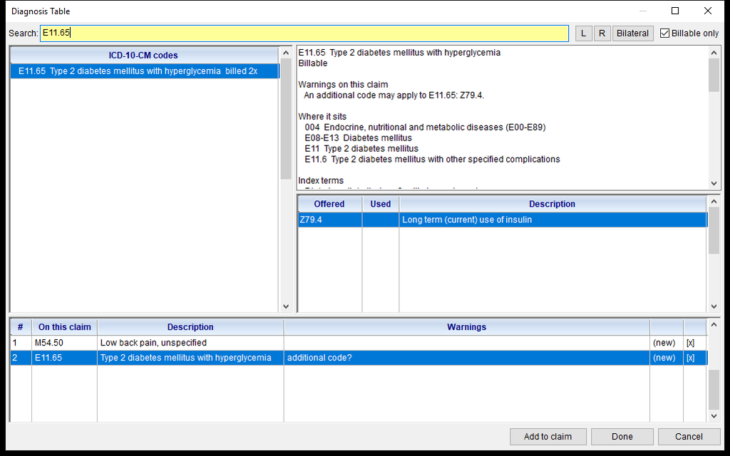

The Diagnosis Table with two new codes on the claim. The first has no warning; the second has a reminder, and the code it offers is in the list under the card

### Step by step

Try these on a claim. Press **Cancel** at the end and nothing changes. The results are ordered by how often your practice bills each code, so your list may be in a different order from the one described here.

**Open the window**

1. Open the claim and click the **ICD10** tab (Alt+C).
2. Click the *IcdCode* cell on the empty row. If the small **…** button does not show inside the cell, press Enter on the cell.
3. Click **…**.

The window opens with the cursor in the *Search* box. It starts on the claim’s first code; on a claim with no codes yet, it starts at the top of the tree with an empty *On this claim* list.

**Type and add**

1. In *Search*, type `low back pain`. Press nothing else: after a short pause the list changes by itself.
2. Click `M54.50 Low back pain, unspecified`. The card on the right shows that code. Read it.
3. Click **Add to claim**.

`M54.50` appears under *On this claim*, marked *(new)*, with an **[x]** beside it. The cursor goes back to *Search*, so you can replace the text there with your next search.

**Paste words from a note**

1. In the report or note, select a few words, such as `pain in knee`, and copy them with Ctrl+C.
2. Clear the *Search* box and click in it.
3. Press Ctrl+V, or right-click and choose **Paste**.

The list follows, the same as when you type.

**Put one side first**

1. With `pain in knee` still in the box, click **R**. `M25.561 Pain in right knee` and the other right-side codes move to the top. Nothing is hidden.
2. Click **R** again to turn it off.

**Use only the keyboard**

1. In *Search*, type the code you already know: `E11.65`.
2. Press Enter, or the Down arrow. The cursor moves to the list.
3. Press Enter on the code. It is added.

**Double-click**

1. In *Search*, type `hypertension`.
2. Double-click `I10`. It has nothing under it, so it is added.

A double-click does different things depending on the row:

| You double-click | What happens |
| --- | --- |
| A billable code with nothing under it | It is added |
| A row with a **+** in the tree | It opens. Nothing is added |
| A gray code with nothing under it | Nothing is added. The line beside the buttons says why |

**Find a code in the tree**

1. Clear the *Search* box. The tree comes back.
2. Double-click `E00-E89`, then `E08-E13`, then `E11`, then `E11.6`. Each one opens.
3. Click `E11.65` to read its card, then click **Add to claim**.

**Choose from the list under the card**

1. In the tree, click a gray code that has codes under it, such as `E11.6`. The **More specific** list shows the codes you can bill.
2. Click one of them. The card changes to that code.
3. Click **Add to claim**. The code you clicked in the list is the one added.

A code that needs a seventh character works the same way. In the tree `S72.001` is one row: **Add to claim** refuses it and says why, and the list under the card has `S72.001A` and the other finished codes. If you search for `S72.001` instead, the results list the finished codes directly.

**Take back a code you just added**

- Click its **[x]**.
- Or click its row in *On this claim* and press Delete.

Only codes marked *(new)* can be taken back here. A code that was already on the claim has no **[x]**.

**Follow a warning**

Add `E11.65`. The *Warnings* column says *additional code?*, in black with no **!**. That is a reminder:

1. Click the `E11.65` row in *On this claim*. The list under the card is now headed *Offered*, and shows `Z79.4 Long term (current) use of insulin`.
2. If the patient uses insulin long term, click `Z79.4` and click **Add to claim**. If not, leave it.

Now search for `E10.9`. Its row in the results starts with **!**, and it says that `E10.9` and `E11.65` are never coded together. You can still add it, and both rows then say *Excludes1 with…* in red. If that was a mistake, click the **[x]** on `E10.9`.

Add `M25.569`, and the column says *side not specified*. Click its row, click `M25.561` or `M25.562` in the *Offered* list, and click **Add to claim**. The new code goes on as another row, so remove `M25.569` with its **[x]**. If `M25.569` was already on the claim, delete it on the ICD10 tab after **Done**, and check the *Diag* on each line.

**Finish**

1. Click **Done**. The window closes with no questions.
2. On the ICD10 tab, the first new code fills the empty row at the bottom, and any others follow it.
3. Click **Save** on the claim. Each code has the number the window showed beside it. That is the number to use in a line’s *Diag*.

To leave without changing anything, click **Cancel**, click the window’s close box, or press Esc.

**Pick one code for an encounter**

1. On the encounter, click the search button beside the diagnosis field.
2. Type your search, and click the code.
3. Click **Use this code**. The field fills in and the window closes.

An encounter dated before October 2015 opens the old ICD-9 list instead.

**Keys**

| Where | Key | What it does |
| --- | --- | --- |
| *Search* box | Enter or Down arrow | Moves to the list |
| List or tree | Enter on a code with nothing under it | Adds the code |
| Tree | Enter on a row with a **+** | Opens the row |
| *On this claim* | Delete | Takes back a new code |
| Anywhere | Tab | Moves to the next part of the window |
| Anywhere | Esc | Closes the window without changing the claim |

### Finding a code

- **Search:** type words, or the start of a code, in the box. The list changes by itself after a short pause, from three characters on. It shows codes that can be billed on the claim’s date of service, the likeliest first. Clear the box and the tree comes back, open where you left it.
- **Nothing found:** the list shows the codes that only mention your words, under a heading that says so. Some of them cannot be billed.
- **L, R, Bilateral:** puts that side’s codes first in the search results and hides nothing. Click it again to turn it off.
- **Browse:** the tree goes chapter, section, category, then each code. A row with a **+** opens with Enter or a double-click. Gray rows cannot be billed on the date of service. *Billable only*, on when the window opens, hides the gray rows with nothing billable under them; it applies to the tree, not to search results.

A code that takes a seventh character is one row. Its finished codes are in the list under the card.

### The code’s card

The card follows the row you select. It says whether the code can be billed on the date of service, and why not if it cannot; where the code sits in ICD-10; and its notes in full, saying which code each one comes from (*from E11*). It also shows the entries of the CMS Index that lead to the code, how often your practice has coded it, and the procedures it is billed with.

When the claim’s payer has refused this code with one of the claim’s procedure codes, *Payer history for this claim’s lines* comes before the rest of the card, after any warnings. A part with nothing to say is left out.

The **More specific** list has the billable codes under the selected one, or the other choices for an unspecified code, most used first. Click one to read its card.

### Adding codes

**Add to claim** adds the code on the card. Enter or a double-click does the same on a code with nothing under it. A code that cannot be billed on the date of service, or that is already there, is not added; the line beside the buttons says why.

*On this claim* lists the claim’s codes in order, then the ones you added, marked *(new)*. The number on each row is the one it will have once saved, which is the number a line’s *Diag* uses:

- **New codes** can be removed: click their **[x]** or press Delete.
- **Codes already on the claim** cannot be moved or removed here. A procedure line points at a diagnosis by its position, so that is done on the diagnosis list: the ICD10 tab on a claim.

### Warnings

The *Warnings* column says what to look at on each code, judged over the whole claim for its date of service. It follows every code you add or remove.

Click a row and its card lists the warnings in full. Codes you can add go to the top of the list under the card, headed *Offered*: click one, then **Add to claim**. A code named by a warning that is already on the claim, such as the other half of an Excludes1 pair, says *Related, on this claim*. Click it to read its card; it cannot be added again.

A warning informs. It never stops you adding a code or pressing **Done**.

**Adding a code does not replace another.** The code you add goes on as a new row at the bottom. A code already on the claim stays where it is, and each line’s *Diag* still points at its position. To be rid of it, press **Done** and delete it on the diagnosis list: the ICD10 tab on a claim, the screen’s own list on an encounter. On a claim, then check every line’s pointers: see Pointing lines at diagnoses.

| The column says | What it means |
| --- | --- |
| *not billable* | The code cannot go on a claim for this date: a header code that has more specific codes under it, retired, not yet valid, or not an ICD-10-CM code. Add the right code, then delete this one. |
| *needs 7th character* | The code is not finished. Add the finished code from the list, then delete this one. |
| *additional code?* | ICD-10-CM says “use additional code”. Add one only if it applies. Some common codes say this every time, so on its own it is in plain black with no **!**: a reminder, not a fault. |
| *Excludes1 with…* | ICD-10-CM says the two codes are never coded together. It shows on both. Keep both only if the two conditions are unrelated. |
| *order with…* | A “code first” instruction asks for the two codes the other way round. It shows on both. Change the order on the diagnosis list. |
| *side not specified* | The code leaves the side open, and codes for the side exist. Add the right one, then delete this one. |
| *patient sex* | The code does not fit the sex on the patient’s record. Shown when you open the window from the code cell’s button. |
| *? checks did not run* | The checks could not be read, and the line beside the buttons says so too. An empty column would not mean a clean claim here; close and reopen the window. |

Every warning but that reminder is in red, with a **!**. A code you just added and no longer want goes with its **[x]**, with nothing else to do.

Old problems show too. A pair saved on the claim long ago has its warning on both rows, though you added neither.

### Closing

**Done** adds the new codes to the bottom of the claim’s list, with no questions. The first one fills the empty row there, if there is one. An empty row between two codes stays as it is, because filling it would renumber the codes under it. Then press **Save** on the claim as usual. **Cancel**, Esc and the window’s close box leave the claim as it was.

The encounter coding screen uses the window the same way. The diagnosis button on an encounter or a discharge opens it to pick one code: there is no claim list and no warnings column, and **Use this code** fills the field and closes. **Tables > ICD10** opens it only to read: no adding, and Esc closes it.

### Run Analizer

**Run Analizer**, on the ICD10 tab, does not open this window. It checks every code on the claim and asks you, one message at a time:

- **A code is not billable** — *ICD10 Code seems invalid*, with the reason. Choose the more specific code.
- **An additional code may apply** — tick the ones that apply.
- **A seventh character is needed** — pick it from the list.
- **A side is needed** — codes for the right and the left side exist under this code; pick one. Only codes valid on the claim’s date of service are offered, so a code that is complete as it is (I60.2, for one) is not asked about. **Analyze 837** reports the same thing as *Lateral digit needed*.
- **Patient sex** — the patient’s sex does not fit a code.
- **Excludes1** — two codes are never coded together. Keep both only if the two conditions are unrelated.
- **Diagnosis sequence** — a “code first” instruction asks for the codes the other way round. Move them.

## Pointing lines at diagnoses

Each procedure line has a **Diag** column: which diagnoses justify it, by their position in the ICD10 list. `1` is the first diagnosis, `1,2` the first and second. Separate numbers with commas.

Two things to watch:

- **Picking a code on a line resets its Diag to 1.** Set the pointers after the codes.
- **Reordering or deleting diagnoses changes what the numbers mean.** After moving or deleting a code, check every line’s pointers.

## Warnings on the encounter coding screen

The screen itself, with its four tabs, is described in *Coding the encounter in Patients10 (institutional)*. This section is about its *Warnings* column.

When one person codes in Patients10 and another bills, a coding problem used to surface only when the biller saw an error tag on the claim and went back to the coder. The **Coding** screen of an encounter now shows the problem to the coder, in its own *Warnings* column, while the case is open. The codes here are the ones the claim uses, so a correction here is a correction on the claim.

The column uses the same words as the Warnings column of the Diagnosis Table, in red with a **!** for anything but a reminder. It is judged when the screen opens, and again after every code you type or pick, delete or move, and after the Diagnosis Table or the AI coding button adds codes.

**To read a warning in full,** double-click its cell, or move to it with the arrow keys and press Enter.

**A pair.** Type `E11.65`, press Enter, then type `E10.9` on the next empty row and press Enter. Both rows turn red: *! Excludes1 with E10.9* and *! Excludes1 with E11.65*. Delete the code that does not belong and the other row clears at once. If the two conditions are truly unrelated, keep both.

**An order.** With `N18.6` above `I12.0`, both rows say *! order with…*. Click the `I12.0` row and press **Move Up**, and the warning clears.

**Save.** If something is still in red, **Save** saves your codes and then lists what to check. It never refuses. It does not repeat the same list while nothing has changed, and the column keeps showing it.

Two limits:

- **Checks that need the claim’s lines stay on the claim.** *Wrong Side ICD10*, *Bilateral CPT, One-Side ICD10*, *ICD10 Relation* and *Denied Before* judge the codes against procedure lines and a payer, which the coding screen does not have.
- **A tag already on a claim stays until the claim is saved again.** After the coder corrects the codes, the biller opens the claim and presses **Save**. The tag then clears by itself if the problem is gone.

# Coding the procedures

## The procedure lines

Each line is one service:

| Column | What it holds |
| --- | --- |
| *BillCode* | The procedure code, followed by its modifiers |
| *Unts* | Units, 1 to 9,999 |
| *Fee* | Your charge |
| *Expected* | What the payer is expected to allow — this is what the claim bills |
| *Deduct* | The patient’s deductible share |
| *From*, *Thru* | Dates of service |
| *Diag* | The diagnosis pointers (above) |
| *Tos*, *Pos* | Type and place of service |
| *Performing* | The performing physician for the line |

Add a line with **New** (*Add a procedure line*), Insert, or the down arrow on the last line. Delete removes the highlighted line straight away.

## Codes, prices and the fee schedule

Type the code in *BillCode*, or click the cell’s button to pick it from **Valid Billing Codes** — the codes your practice has priced **for this claim’s payer**, as of the date of service. When you pick or confirm a code, Mp10 fills in *Fee*, *Expected*, the description, the revenue code, the place and type of service, and the deductible.

**Valid Billing Codes** opens only when you ask for it: the cell’s button, or Enter on the *No matches* row of the list under the grid. It no longer opens by itself when you leave an empty cell or type a code the payer has no price for. It lists the codes billed most often on this payer’s fee schedule at the top. Its *Billed* column shows how many claim lines used each code in the last 12 months. Typing a code still jumps to it, and clicking the *Cpt Code* header sorts the list by code.

Prices come from your practice’s billing codes table, kept by payer and by effective date in MpAdmin. If you type a code that is not priced for the payer and press Enter, the cell stays open and the list under the grid says *“76999” is not on the MCS fee schedule*, with the priced codes that start the same way, so you can correct it or pick one. If you leave the cell instead, the line keeps the code it had, and you hear a beep. If the code is not on the fee schedule at all, ask whoever keeps the fee schedule to add it.

A code with a modifier the fee schedule does not list is still accepted and priced from its first five characters: `76881 XY` takes the price of 76881.

Changing the units changes *Expected* and *Deduct* in proportion.

### Anesthesia price

Anesthesia is paid by units, and the fee row is not the rate. For a payer that has an **Anesthesia Rate** (see *Setting it up*, under Auto-claim), a line billed with an anesthesia code (00100-01999) is priced by formula when you type or change its code, units or modifiers, in PrBill10 and MpBill10:

> price = (units + base units + P units) × rate
- **Base units** are the CMS base units of the code, in force on the date of service. A payer whose claims already include them in *Unts* has base units counted as 0.
- **P units** are added only for a payer set to add them: P3 adds 1, P4 adds 2 and P5 adds 3, as in the ASA convention.
- **Rate** is the payer’s dollars per unit on the date of service.

Hover over the *Fee* cell to see how its price was made. You can still overwrite it. A payer with no rate is priced as other lines are, from the fee row.

**Units and physical status from the encounter.** Where the practice records anesthesia times on the encounter (**BILLING / ANESTHESIA-TIME** at `YES`), adding an anesthesia code fills *Unts* from them instead of 1: the minutes divided by 15, rounded up, plus the CMS base units for a payer whose rate says its units include them. Hovering the *Unts* cell shows how, for example *anesthesia 07:42-08:31, 49 min = 4 time units + 5 base*, and the button in the cell recalculates the line from the encounter’s times. When the encounter records a physical status and the payer bills one on at least 20% of its anesthesia lines, the code gets it as its last modifier (`00731AA` becomes `00731AAP2`); a status you type on the line is kept. Lines already on the claim do not change when the encounter is corrected later: use the button, or type the code again. The *Mp10 for Anesthesia Practices* guide, chapter *On the claim*, has worked examples.

The **patient quote** prices its anesthesia line the same way, with the units the payer usually bills for that code.

## Fee schedule dates

A price in the billing codes table has an **effective date** and, once it is replaced, an **expiry date**. The claim is priced with the row in force on the date shown in its *From* column (the admission date on most plans, or the charge’s date on a plan that is set to use it), so a claim for an old service date still gets the old price after a new one is entered. A code with no dated row on the payer’s schedule is priced as it always was.

In the **Fee Schedule** screen in Admin (the *Fee Schedule* link) the grid shows only the rows that are **not expired** on the date in the **In force** box, which opens on today. Rows with a future effective date are listed too; only closed history is hidden. Pick a payer in *Filter Only* and the list follows; change the date to hide or show rows by their expiry. Tick **Show all** to list every row of the payer, expired ones too (the date goes grey). A row you add with a future effective date shows at once.

Most rows have **no dates at all**, and that is normal: a row with no effective date has always been in force, and one with no expiry date still is. Dates appear only on rows that have been replaced (the old row gets an expiry date, its replacement an effective date), whether a person replaced them or the quarterly ASC update did.

Where the practice bills Medicare as a surgery center, AutoTasks can add the dated rows itself every quarter; see *Surgery center (ASC) fee schedule* in the *Mp10 AutoTasks — Administrator’s Guide*.

## Finding a code by words

You don’t need to know the code. Type words in the *BillCode* cell, such as `ext sono` or `lap chole`. After three letters, a list opens under the grid with this payer’s priced codes that match, best first. The list narrows as you type.

The words are matched against every description your practice has used for a code: the fee schedules of all your payers and the descriptions on past claim lines. That is why abbreviations and Spanish wording that your office has used find the code. When a code matched through one of those other wordings, its row shows it on a second line: *as billed: EXTREMITY SONOGRAM LTD*.

The list has five columns: *Code* (with its modifiers), *RevCd* (the revenue code of the fee schedule row; blank when it has none), *Description*, *Billed* (how many claim lines used the code on this fee schedule in the last 12 months; blank if none) and *Fee* (this payer’s price). Rows are one line high, unless some row has an *as billed* line; then every row is two lines. Codes whose modifier you typed rank first: `sono rt` puts the RT codes on top.

**One row per code and revenue code.** When the payer’s fee schedule prices a code on more than one revenue code (a surgery on 490 for the operating room and on 272 for the materials, say), the list shows each one as its own row, with that row’s own description and fee. Picking a row gives the line that revenue code, description and fee. Both rows show the code’s one *Billed* count.

**What is already on the claim is not offered again.** A code and revenue code that another line of the claim already has is left out of the list. On an empty line, the other revenue codes of a code already on the claim come first: after 47562 on 490, the next line’s list opens on 47562 on 272.

Typing the start of a code (`7688`) lists the priced codes that start with it. A full code followed by Enter works exactly as before, even if the code is already on the claim: it is priced from the same fee schedule row a typed code has always been priced from.

- **Down arrow**, or **Enter** after words, moves from the cell into the list.
- **Enter** or a **double-click** picks the highlighted code. It fills the line as if you had typed the code, and the cursor moves to an empty line at the bottom.
- **Esc** closes the list. The cell keeps the code it had.
- Words are never saved as a code. If you leave the cell without picking, it goes back to the code it had.
- Leaving an empty *BillCode* cell (up arrow, Tab, a click elsewhere) does nothing. The line stays empty.
- **No matches:** press Enter on the *No matches* row to open **Valid Billing Codes**. That and the cell’s button are the only ways it opens.

**Suggestions.** On an empty procedure line, on either the *Summary* or the *Procs* tab, the list opens by itself with the codes most billed on this payer’s fee schedule. It does not take the cursor. Press the down arrow to move into it, or type to search instead. Arriving on the *Procs* tab puts the cursor on an empty line at the bottom; an empty line is never saved. Returning to the *Summary* tab leaves the cursor in the claim’s header.

On a closed claim the *BillCode* cell works as before, with no list.

**Where the list opens.** While the list is open, the grid’s totals row is hidden to leave room for lines. On the *Procs* tab the list takes the bottom of the grid. On the *Summary* tab, where the grid is short, the grid shrinks to half its height and the list fills the rest of the page, over the balances, dates and facility fields. Those come back as soon as the list closes: after a pick, Esc, or a change of tab.

The counts are refreshed every night. Until the first count after the Data Dictionary update, the list searches the fee schedule’s own descriptions only, offers no suggestions, and *Billed* shows 0.

## Modifiers

Type modifiers **after the code, separated by spaces**: `76881 TC RT`. Up to four are sent. If your fee schedule prices the code with its modifiers as a separate entry, that price is used; otherwise the base code’s price is. After the price fills in, check the modifiers are still on the line.

## Checking a batch of claims before sending

In the Claims grid, select claims and click **Analyze 837** in the side panel. Mp10 reviews them all and prints a list of warnings: missing or invalid codes, duplicate diagnoses, codes that need a seventh character or a side, missing place of service, the tags each claim carries. Nothing is changed or sent.

# Coding the encounter in Patients10 (institutional)

In a hospital or facility the codes are usually set by the record room, not by the biller. The coder works in **Patients10**, on the encounter’s **Coding** screen, and the biller finds the result on the claim in **MpBill10**. This chapter is for that coder. It covers both kinds of institutional case:

|  | Inpatient stay | Ambulatory / outpatient case |
| --- | --- | --- |
| Diagnoses | **Icd10s** tab, with **POA** on every code | **Icd10s** tab; POA is not needed |
| What was done | **ICD-Procs** tab: ICD-10-PCS codes, each with its date | **Cpts** tab: CPT/HCPCS codes, with units |
| The other tab | **Cpts** only if the payer also asks for CPT codes | **ICD-Procs** stays empty |

ICD-10-PCS is the code set for procedures on hospital **inpatient** claims. Outpatient and surgery-center claims report procedures with CPT and HCPCS codes instead. Mp10 follows that rule when it sends the claim: see *What billing does with the codes* at the end of this chapter.

## Opening the Coding screen

1. In Patients10, open the **Encounters Table** and highlight the encounter.
2. Click **Coding** in the side panel.

The window is titled *ICD codes*, with the encounter number and the patient’s name. It does not block the rest of Patients10: you can leave it open, look at the encounter or the patient, and come back. Asking for the same encounter’s coding again brings the open window forward instead of opening a second one.

It has four tabs: **Icd10s**, **Icd9s**, **Cpts** and **ICD-Procs**. Each one is a list with the same four buttons on the right:

- **Add** adds an empty row. An empty row is never saved.
- **Delete** removes the highlighted row.
- **Move Up** and **Move Down** change the order. The order matters: the first diagnosis is the principal diagnosis, and the first ICD procedure is the principal procedure.

On the Icd10s and Cpts tabs the keyboard does the same: Ins or F5 adds, Del or F6 deletes.

**Save** (bottom of the window) saves all four tabs at once. **Exit** closes without saving.

On every tab you can simply start typing on a cell; you do not need to press Enter first.

## The Icd10s tab: diagnoses

This tab works like the claim’s ICD10 tab, described in *Coding the diagnoses (ICD-10)*: type a code with its dot in *Icd10*, or type words in *Description* and pick from the list that opens under the grid. The cell’s button, and Enter on the list’s *No matches* row, open the Diagnosis Table. The button with the AI icon reads the encounter’s reports and proposes codes.

What is different here:

- **POA** (present on admission). The column appears only on an **inpatient** encounter, because POA is not reported on any other claim. Answer it for every diagnosis: after Enter on a code the cursor moves along the row, so you pass through POA on the way. See *Present on admission (POA)* below.
- **DateCoded** and **Operator** show when the code was entered and by whom. You do not type them.
- **Suggestions on an empty row** are the diagnoses your facility has billed most often with the codes on this encounter’s **Cpts** tab. Code the Cpts first and the suggestions fit the case.
- **Warnings.** The *Warnings* column judges the codes while you work. See *Warnings on the encounter coding screen*.

The **Icd9s** tab is only for encounters before 10/01/2015. Leave it alone on anything newer.

### Present on admission (POA)

POA says whether the patient already had the condition when the inpatient stay began. Payers use it to tell a condition the patient arrived with from one that developed in the hospital. Pick one of these in the *POA* cell:

| POA | Meaning |
| --- | --- |
| **Y** | Present at the time of admission |
| **N** | Not present at admission: it developed during the stay |
| **U** | The documentation is not enough to tell |
| **W** | The provider cannot determine it clinically |
| **1** | This code is exempt from POA reporting |
| blank | Not answered yet |

Resting the mouse on the cell shows the same list.

- A new diagnosis starts **blank**. Mp10 never fills in an answer for you.
- Use **U** only when the record truly does not say. It is not the same as leaving the cell blank.
- **1** is for the codes on the official list of POA-exempt codes (many external-cause and “history of” codes, for example). Nothing is sent to the payer for an exempt code, which is what the payers expect.
- The answer belongs to the code. If the biller later moves or deletes diagnoses on the claim, each code keeps its own POA.

A claim that needs POA and has a diagnosis left blank is tagged **POA Missing**; see *What billing does with the codes*.

> The POA cell used to offer only Y and N, and its answers were never sent correctly. Answers entered before this version are not kept: on an inpatient encounter coded earlier, answer POA again.

## The Cpts tab: procedures of an ambulatory case

One row per code: *Cpt*, *Description* and *Units*.

- **If you know the code,** type it in *Cpt* and press Enter. Its description fills in. The code must be one of your facility’s billing codes.
- **If you do not,** type in the *Description* cell. An empty row shows the gray hint *Type a code or keywords, e.g. 6698 or cataract*. After three characters a list opens under the grid and narrows as you type. Words are matched against every description your facility has used for a code, so your own abbreviations find it.
- **Down arrow**, or **Enter** after words, moves into the list. **Enter** or a double-click picks the code. **Esc** closes the list.
- **No matches:** Enter on the *No matches* row opens the full list of billing codes. The *Cpt* cell’s button opens it too.
- Type the **Units** when there is more than one.

What you type in *Description* is only a search. It is never saved; the description saved is the code’s own.

**Which codes the list offers.** The list is taken from the fee schedule of the encounter’s payer, as it stands on the admission date. Coding is not pricing, so the list is more generous than the one on the claim:

- a code appears once, whatever revenue codes the schedule prices it on;
- a code is offered even if the payer has no fee for it;
- when the payer has no fee schedule, or nothing on it matches, the list comes from all your fee schedules.

**Suggestions on an empty row.** The list opens by itself, with a heading that says where it comes from: *Billed with this encounter’s diagnoses, then most billed* when the Icd10s tab already has codes, otherwise *Most billed on the … fee schedule* or *Most billed on all fee schedules*. Codes already on the tab are left out.

## The ICD-Procs tab: procedures of an inpatient stay

One row per procedure: *IcdProc*, *Description* and *Date*.

An ICD-10-PCS code is **seven letters and digits with no dot**, for example `0DTJ4ZZ` (laparoscopic removal of the appendix). The letters I and O are never used, so they cannot be mistaken for 1 and 0. The code set is not only surgery: imaging, transfusions, deliveries, radiation therapy and rehabilitation done during the stay have codes too. That is why the third column is called *Date* and not *surgery date*.

There are three ways to enter a procedure.

**Type the whole code.** Type the seven characters in *IcdProc* and press Enter. Lower case and dots are corrected for you. If the code exists, its title fills *Description*. If it does not, Mp10 says *“…” is not an ICD-10-PCS procedure code* and empties the cell.

**Search as you type.** An empty row’s *Description* cell shows the gray hint *Type part of a code or keywords, e.g. 0DTJ or appendix resection*. Type either one there:

- **keywords**, such as `appendix resection` or `knee replacement right`. Every word has to be in the code’s title, and the start of a word is enough: `append resect` finds the same codes;
- **the start of a code**, such as `0DTJ`. This also works in the *IcdProc* cell.

After three characters a list opens under the grid with *Code*, *Description* and *Used* (how many encounters at your facility carry the code). It shows up to 50 codes, in code order; type more to narrow it.

- **Down arrow** or **Enter** moves into the list.
- **Enter** or a **double-click** picks the highlighted code and fills the row. The cursor goes to a new empty row.
- **Esc** closes the list.
- **No matches:** press Enter on the *No matches* row to open the procedure code table (below).

A partial code is never saved as a code. Enter on less than seven characters takes you into the list, not out of the cell.

**Open the procedure code table.** The *IcdProc* cell has a button. It opens *ICD-10-PCS Procedure Codes*, one window with a search box over the whole table:

1. Type part of a code or keywords in **Search by code or keywords**. The list updates a moment after you stop typing. With the box empty the table is listed from its first code.
2. Move to the code with the arrow keys or the mouse.
3. Press **Enter**, double-click, or click **Select**. The code and its title go to the row. **Cancel** or Esc leaves the row as it was.

The window shows up to 500 codes at a time and says so above the list; add a word to see fewer.

**Suggestions on an empty row.** Under the heading *Procedure codes used most here*, the list offers the procedure codes your facility has coded most often, most used first, leaving out the ones already on this encounter. A facility that has just started coding in ICD-10-PCS sees no suggestions until some encounters have been coded.

**The date.** *Date* starts as today’s date. Change it to the day the procedure was done; the payer receives it with the code.

## Saving

**Save** writes all four tabs. If the *Warnings* column of the Icd10s tab still shows something in red, your codes are saved and Mp10 then lists what to check. It never refuses to save.

## What billing does with the codes

The codes belong to the **encounter**. Every claim of that encounter uses them, and the biller does not type them again.

- **In MpBill10’s claim window, the *Rec Room* tab** shows the encounter’s diagnoses, ICD procedures and CPT codes as the coder left them, to read.
- **Diagnoses** go on the claim in the order of the Icd10s tab. The first one is the principal diagnosis.
- **POA** is sent with each diagnosis, the principal one included, on an **inpatient** claim, whatever the payer. The payer gets exactly what the coder answered: Y, N, U or W. A code marked exempt (1) and a code left blank send nothing.
- **POA Missing.** When such a claim is saved with a diagnosis still blank, it is tagged **POA Missing**. Clicking the tag names the codes. The coder answers them on the Coding screen, the biller saves the claim again and the tag clears. The tag warns; it does not stop the claim.
- **ICD procedures** are sent only on an inpatient claim: the first row as the principal procedure, the rest as other procedures, each with its date. They also print on the paper UB-04. On any other claim they stay on the encounter and are not sent.
- **POA on the paper UB-04.** The form prints POA only where its layout asks for it. In the form’s script, `^POA[1]` is the POA of the diagnosis that `^ICD[1]` prints, `^POA[2]` of the second, and so on: Y, N, U or W on an inpatient claim, and nothing on any other claim, for an exempt code, or for one not answered. On the UB-04 the POA is the eighth character of each diagnosis box (FL 67 and 67A-Q), so a diagnosis line of the form reads `~PADR( "^ICD[1]", 7 ) + "^POA[1]"~`. A form whose script does not use `^POA` prints as it always has.
- **MpWeb.** The claim window of MpWeb shows the same POA column on an inpatient claim, with the same six choices, and tags **POA Missing** by the same rule.

**Which claims are inpatient.** A claim is inpatient when its type of bill starts with **11** (hospital inpatient). The third digit only says whether the claim is an original, a replacement or a void, so all of them carry POA and the ICD procedures. The type of bill comes from the payer’s record when it has one, otherwise from the encounter’s admission type.

**Every payer receives POA on an inpatient claim.** There is no setting: Medicare and most other payers require it there, and a payer that does not use it ignores it. The hospital types that are exempt from POA reporting (critical access, psychiatric, rehabilitation, long-term care and the like) may still send it.

- **CPT codes** from the Cpts tab are the record room’s coding of the case. The claim’s lines still come from the charges posted to the encounter, so the biller compares the two on the *Rec Room* tab.

If the coder changes a diagnosis after the claim was made, the biller opens the claim and presses **Save** so its error tags are judged again.

## For the administrator: the ICD-10-PCS table

The search, the suggestions and the check of a typed code need the CMS ICD-10-PCS code set in your data. It arrives in two steps.

1. **Update Data Dictionary** (version 10.99 or later) creates the table and its search index. The same update adds the new POA field to the diagnoses; until it has run, the Coding screen shows no POA column and no claim carries POA. Until then the ICD-Procs tab works as it always did: the code is taken as typed, with no list and no check.
2. **Load the codes.** In MpAdmin10: **File → Code Sets → Download ICD-10-PCS Procedure Codes from CMS**. Answer **Yes**. It downloads the current release from cms.gov and loads it in under a minute, then names the release and the file it came from. The computer needs internet access.

After that nothing has to be done by hand. AutoTasks looks at the CMS site at each of its checks and loads a new release when one is in force: the new fiscal year every October 1st, and the April 1st update when CMS publishes one. Each release is a whole code set and replaces the one before it. The *Mp10 AutoTasks* guide describes it under *Keeping the CMS reference data current*.

Run the menu item again at any time to check: if the newest release is already loaded it says so, and offers to download and load it again.

A code already on an encounter is never changed or removed by a new release.

# Saving the claim, and error tags

## When you save

Click **Save**. Mp10:

- refuses a new claim with no lines (*Nothing to save*);
- warns if the same codes, dates and payer are already billed for this patient (*Billing Codes, dates, and insurance seems to be duplicated*) — answer No if it is a duplicate;
- refuses a payer that is not set up in your insurance list;
- refuses a line with more than 9,999 units, with negative units, or with an amount too large to store, and names the line. A billing code typed into *Unts* by mistake is the usual cause;
- asks before saving a line with more than 999 units, or with an *Expected* more than ten times *Fee* × units. The answer is No unless you choose Yes;
- gives a new claim its number;
- runs the **claim checks** and tags the claim with what they find.

If anything fails, nothing is saved: *The claim was NOT saved. Everything from this save has been rolled back*, followed by the reason.

## Error tags

A **tag** is a coloured label at the bottom of the claim window naming a problem a check found: *Wrong Side ICD10*, *ICD10 Relation*, *NCCI Pair Needs Modifier*, *Denied Before*, and others. Tags never stop you from saving or sending a claim. They tell you what a payer is likely to reject, before it does.

- **Hover a tag** to see what it found.
- **Click it** for the full explanation: which lines, which codes, and why.
- **To clear it,** fix what it names and save. Each check runs again on every save and removes its own tag when the problem is gone.

Three checks offer to fix the problem for you as you save, and change nothing unless you answer Yes:

- **Insurance DOB Mismatch** — the payer’s last eligibility answer gives a different date of birth. Yes writes the payer’s date on the patient’s insurance card, not on the patient.
- **Insurance Sex Mismatch** — Yes updates the patient’s record.
- **Payer Not On Patient** — the claim bills a payer the patient has no card for. Yes adds it to the patient’s insurances; check the member number and dates afterwards. Answer No if the claim is the one that is wrong.

Three tags learn from the remittances you post (Part III): **Denied Before**, when this payer has refused these codes often and recently; **Refused For This Patient**, when the payer refused these very codes for this patient and has paid nothing for them since; and **Missing Performing Physician**, when the claim has none and this payer has refused claims sent without one.

**Prior Auth Missing** does not learn anything: it follows the **Prior Auth Rules** table your supervisors keep. See the chapter *Prior authorizations*.

**POA Missing** (institutional) is placed on an inpatient claim when a diagnosis of the encounter has no POA answer. Answer it on the encounter’s Coding screen and save the claim again. See *Coding the encounter in Patients10 (institutional)*.

**Physical Status Missing** is placed on an anesthesia-code line with no P1-P6 modifier, for a payer whose anesthesia lines carry one at least 20% of the time. It runs on every claim you save, hand-made or auto-created. Add the modifier and save. Where the encounter’s Anesthesia tab records the physical status, anesthesia lines added after that get it, by hand or by Auto-claim, and do not raise the tag.

You can also add your own tag with the **+** button beside the tags, to mark a claim for yourself or a colleague.

The full list of checks, what each looks for and how to switch one off is in the *Mp10 Dashboard* guide, chapters *Claims with error tags* and *The claim checks*. The dashboard’s *Needs attention* card lists every claim tagged in the last seven days.

In the Claims grid, a claim with tags shows a tag icon in *SrvDate* and its row is coloured orange. Click the icon to see all the claim’s tags in a small note beside it, without opening the claim. The click works on the selected row; on another row, the first click selects it and a second click shows the tags.

# Prior authorizations

Some payers refuse a service unless the claim carries a prior authorization number. A payer can start asking for one at any time, and its refusal does not always say so: the reason may name something else entirely. By the time the refusals arrive, weeks of claims may already have gone out without a number.

Mp10 cannot know what each payer requires, so your practice keeps a list of it, the **Prior Auth Rules** table. When a claim for one of those services has no number, it gets the **Prior Auth Missing** tag, and the biller sees that before sending the claim.

The table starts empty, and **with no rules this tag is never placed**.

## Where the number goes

There is one number per visit. It can be entered in two places:

- On the encounter, in *Prior Auth*. This is the natural place when the front desk has the number before the visit.
- On the claim, in *Pre-Auth Numb.*

A new claim takes the encounter’s number, including one made by auto-claim. If the number arrives later, enter it on the encounter and save the claim: a blank claim takes the encounter’s number when you save. A number already on the claim stays as it is.

The number goes to the payer on the claim. A value containing **ACC:** in the claim’s field is not sent as an authorization, so it counts as no number.

**Institutional:** the encounter window has its own prior authorization field, and it works the same way.

## The Prior Auth Rules table

Open it from any of these:

- In PrBill10 or MpBill10: *Tables → Prior Auth Rules*, or the **Prior Auth** button on the toolbar, after the ICD10 button.
- In PrAdmin10 or MpAdmin10: *File → Prior Auth Rules*.

Supervisors and administrators can add, change and delete rules. Anyone else who can open the table can read it and can list the claims a rule matches.

It works like Insurance Companies: the rules are listed on top, and the highlighted rule’s details show below. You can leave it open and work elsewhere. When you go to another browser it hides, and when you open it again it is as you left it.

| Field | What it means |
| --- | --- |
| *Insurance* | The payer, as it appears in your insurance list. Type it, or use the magnifying glass to pick it. **Leave it blank for every payer**: the rule then shows as *All payers* |
| *From code*, *To code* | The range of billing codes, five characters each. For one code, enter it in both. Modifiers do not matter: a rule for 72148 also covers 72148 TC |
| *From date*, *To date* | The dates of service the rule covers. A blank date is an open end |
| *Notes* | Anything worth keeping: who at the payer said so, or the notice it came from |
| *Changed by* | Filled in by Mp10 with the user who last saved the rule |

### Adding a rule

1. Press **New** (or Insert). The fields below the list open for typing.
2. Pick the payer, or leave *Insurance* blank for every payer.
3. Enter *From code* and *To code*.
4. Enter *From date*: the day the payer began requiring the number. Leave *To date* blank unless the requirement has ended.
5. Press **Save**. **Cancel** discards what you typed.

A payer that requires a number for several separate groups of codes needs one rule per group. For example, a payer that asks for a number on head and spine MRI, starting February 1, would have two rules:

| Insurance | From code | To code | From date | Notes |
| --- | --- | --- | --- | --- |
| *the payer* | 70551 | 70553 | 02/01/2026 | Head MRI |
| *the payer* | 72141 | 72158 | 02/01/2026 | Spine MRI |

Set *From date* to the real start. Without it, the rule also matches every older claim for those codes when that claim is next saved.

Use a blank *Insurance* with care. It tags those codes for every payer, including the ones that have never asked for a number.

### Changing and deleting

- **Edit**, Enter or a double-click opens the highlighted rule for changes.
- **Delete** (or the Del key) removes it, after asking once.
- **Print** previews all the rules, grouped by payer.

Renaming a payer carries over to its rules. A payer that still has rules cannot be deleted until they are.

## What happens on a claim

Mp10 checks each time a claim is saved. The claim gets **Prior Auth Missing** when all of these are true:

- The claim has no number.
- A rule names the claim’s payer, or names no payer.
- The date of service falls within the rule’s dates.
- A code on one of the claim’s lines falls within the rule’s codes.

Click the tag to see which payer, code and start date caused it. To clear it, enter the number on the encounter or on the claim, then save the claim.

A few things to expect:

- **The tag warns and never blocks.** It does not stop you saving the claim, and it can sit beside *Denied Before* on the same claim.
- **Auto-claim still creates the claim.** It does not skip the encounter; the new claim simply carries the tag.
- **A complementary claim you save is checked against its own payer**, not the primary’s.
- **A claim with no payer is never tagged.**
- **Mp10 Web follows the same rules** when it saves a claim, but the table is kept only in the Windows programs.

## Finding the claims a rule matches

A claim only gets the tag when it is next saved, so a new rule changes nothing on claims already saved. To see those claims, highlight the rule and press **Show Matching Claims**. This is also a good check on a rule you have just added. The list only reads: it changes nothing.

It opens a little lower and to the right of the rules window, with one line per claim line: the status flag and claim number, the record number, the date of service, the code, the payer, and whether the claim is closed.

- **Only claims still worth acting on are listed.** Fully paid and overpaid claims are left out. Tick **Include paid claims** to see them too.
- **Double-click a line, or press Open Claim,** to work on the claim. In the Admin programs the list only shows the claims and cannot open them.
- **Double-click the record number** to open the patient.
- **Print** previews the list as a report, grouped by code, with a total.

Claims that get their number drop off the list when you close them. The list, and any claim or patient opened from it, hide and come back with the rules window, and close with it. Changing or deleting a rule closes that rule’s list.

## Deciding what goes in the table

Mp10 does not work these rules out for you. A person adds one when a payer says it requires a number, because a refusal alone does not prove it. If a payer starts refusing a service it used to pay, and claims with a number are the ones getting paid, ask the payer; then add the rule from what it tells you.

# Quoting a service to a patient

Before the visit, the front desk can answer “what will I owe?” with a **patient quote**: an estimate that adds up the services, prices them on the patient’s plan and applies the deductible and the patient’s share.

## Opening it

- **With a patient:** in the patient browser, the side panel has **Quote Serv**. It opens with the patient’s name (greyed), the patient’s plan picked, and the coverage on file (the insurance’s deductible string) shown as a hint. Patients10, MpBill10 and PrBill10 all have it.
- **Without a patient:** in the billing program, **Tables → Patient Quote**; in Patients10, **Actions → Patient Quote**. The name is typed. Use this for someone who has no record yet.

## Making a quote, step by step

1. Open the quote (above).
2. Pick the **Plan**, and the **Anesthesia plan** if anesthesia is to be quoted too.
3. Type the patient’s name if it is not filled in, then the **Patient share** and the **Deductible remaining** from the patient’s card.
4. In the grid’s **Code** cell, type a code or words from its description and pick the service from the list. Press Enter (or **Add line**) for the next one. Use **Anesthesia line** for the anesthesia.
5. Check each line’s price and *Priced from*, and type a price where a line asks for one. The totals under the grid show what the services add up to and what the patient owes.
6. Press **Print**. This **saves** the quote and opens the estimate, which you print, or export and e-mail, from the preview.
7. Press **Close**.

There is no Save button: **Print is what saves a quote**. Closing without pressing Print saves nothing, and a saved quote cannot be changed. To correct one, change the quote and press Print again: that saves a new quote with a new number.

## Filling it in

| Field | What to enter |
| --- | --- |
| **Plan** | The patient’s insurance, chosen from the active plans |
| **Anesthesia plan** | Optional. Anesthesia is billed on its own plan, so pick it here to quote the anesthesia too; with *None* the Anesthesia line button stays off |
| **Patient** | The name, typed when there is no record |
| **Patient share** | The choice **%** or **$** and the amount, from the patient’s card. A percentage cannot be over 100. A flat amount is capped at what the line costs after the deductible |
| **Deductible remaining** | What the patient still has to meet. It comes off the dearest lines first, and the patient owes it |

Add each service in the grid’s **Code** cell: type the code or words from its description and pick it from the list. On the empty row the list opens with the plan’s most billed codes. The button at the right of the cell opens the full list of the plan’s billing codes (*Valid Billing Codes*, the same list as the claim’s), most billed first. Press **Add line** (or Enter) for the next. **Anesthesia line** puts the cursor on a new row that is priced on the anesthesia plan; its *Plan* column says so. **Delete line** removes one. A line’s *Share* and *Share value* can be changed on that line, which overrides the top.

A code the plan has no price for is accepted too. It is priced from the CMS rate when the practice uses the ASC fee schedule (the *Priced from* column says *CMS rate*); otherwise it says *No price: type one* and you type one in *Price*. Pressing **Print** with lines still unpriced asks *Print anyway?*, and they print as $0.

*Priced from* says where each price came from: *Fee schedule*, *CMS rate* or *Typed*.

### Surgery center plans

Where the practice bills Medicare as a surgery center and the ASC fee schedule is on, the quote follows Medicare’s rules for the plan that uses it:

- when there are two or more surgical services, the dearest is full price and each other that takes the multiple-procedure reduction is **half**;
- a service that Medicare packages with another (indicator N1) is shown as *Included (packaged), $0*, and its price cannot be typed;
- a device, lens or tissue that Medicare’s contractor prices by invoice (indicators F4, J7, K7 and L6) says *Priced by invoice (Medicare’s contractor): type one*, and prints *Precio por factura* until a price is typed;
- a code Medicare may not pay for shows a **warning** in red.

## Printing, and when a quote is saved

Press **Print**. This is also what **saves** the quote: closing without pressing Print saves nothing. The estimate that opens is in **Spanish**, carries the quote’s number and says that it is an estimate and does not include the surgeon’s fees. Pressing Print again without changing anything shows the same quote again (*Unchanged: quote N again, not saved twice*); any change makes a new quote. If the practice’s data dictionary has not been updated, the quote still prices and prints, but is not saved, and says so.

## Saved Quotes

**Saved Quotes** in the quote window, in the patient browser’s side panel, or in Patients10’s **Actions → Saved Quotes** lists the quotes that were printed, newest first. It opens on the last 90 days (change *From* and *To* and press **Show**). From a patient’s browser **This patient only** is ticked; untick it to see everyone’s.

| Column | Shows |
| --- | --- |
| Date | When it was printed |
| Patient | The patient’s name now (for a linked patient), or the typed name |
| Plan | The insurance |
| Total | The services added up |
| Patient owes | After deductible and share |
| User | Who printed it |

**View** lists a quote’s lines. **Reprint** shows the same estimate with the same number and saves nothing. Quotes cannot be edited or deleted.

# Finding claims

Open the **Claims table** from the toolbar (or *Tables → Claims*). The *Claims Data Grid* lists every claim.

## The columns

*ClaimKey*, *Creation*, *MedRec*, *Encounter*, *SrvDate*, *Contract* (the member ID), *Insurance*, *BillDate*, *Name*, the charge (*Real Amt*), insurance paid, adjusted and balance, the deductible, patient paid, balance and adjustments, the user who last saved the claim and the performing physician.

The *ClaimKey* column shows the claim’s **status flag** (next chapter). Right-click it, or press F9, to see the claim’s status history.

The *SrvDate* column shows a tag icon when the claim has tags. Click it to see all of them in a small note beside it, without opening the claim; on a row that is not selected, the first click selects it and a second shows the tags.

## The row colours

| Colour | Means |
| --- | --- |
| Orange | No bill date, no diagnoses, or the claim has tags |
| Cyan | Resubmitted: corrected, replacement or void |
| Magenta | Created by AutoTasks, Mp10’s automatic service |
| Grey | No charge or no service date |
| Blue | Everything else |

## Filtering

The *Filter* panel on the left narrows the grid by any combination of:

- **Status** — one flag, or *Missing Flag* for claims with no status at all (no flag, or the *Null* flag 0);
- **Ins** — one payer;
- **Srv From / Srv Thru** — dates of service;
- **Bill From / Bill Thru** — billing dates;
- **Wrk From / Wrk Thru** — the date the claim was created;
- **Med Rec** — one patient;
- **User** — the user who **last saved** the claim, the grid’s *User* column. Type the whole user code; capitals or not does not matter, and `AM` does not also find `AMX`. On an auto-created claim this is the person who reviewed it in the claim window, or, if nobody has, or it was cleared with **Mark reviewed**, the person who pressed Auto-claim;
- **Primary claims only** — leaves out complementary (secondary) claims;
- **Hide unreviewed** (PrBill10) — leaves out auto-created claims that nobody has reviewed yet: the claims listed in *Auto-claims to review*. Claims cleared with Mark reviewed count as reviewed here. It is off when the grid opens; ticking it also switches the filter on, if it was off. Like the rest of the filter, it also governs **Select All**, **Outbound 837** and printing, so a reviewed group can be found and sent from here. Outbound 837 honours a ticked box even with the filter switched off. It does not stop anything: with the box unticked, unreviewed claims can still be sent.

Switch the filter on with its LED. To jump to one claim, sort by *ClaimKey* and press F8.

Any number of the options can be set at once. If the database ever refuses a filter, a message says so, the filter is switched off and every claim shows: clear one or more options and switch it on again.

### Filter From File: claims from a list you have

**Filter From File**, the last link in the side panel, shows exactly the claims on a list you have: a payer’s rejection report, a spreadsheet from a collections review, an email with claim numbers in it. The window opens with an empty list; fill it, check it, and click *Run Filter*.

**Filling the list:**

- **From a file.** Click the magnifier beside *Filename* and pick the file. Every claim number in it is listed, wherever it sits in the file: one per line, several on a line, inside a sentence, in any column of a spreadsheet. PDF, Excel (*.xlsx* and the older *.xls*), Word (*.docx*), text, CSV, tab-delimited, XML, web pages and scanned images (TIFF, PNG, JPEG, read by OCR) all work.
- **PDF files.** A PDF from a payer portal or a clearinghouse holds real text and is read at once. A **scanned** PDF is only pictures of pages: Mp10 reads each such page with OCR, the same reader that fills in insurance cards, which takes a few seconds a page. A window shows which page it is on; *Cancel* stops after that page and keeps the claims already found. OCR can misread a smudged number, so compare the count with the report — a number it cannot read whole is left out, never guessed. If the window says the OCR files are missing, the workstation can still read text PDFs; scanned pages need the card-reading files installed.
- **By pasting.** Copy any text that holds claim numbers, click in the list, and press Ctrl+V. Only the claim numbers are taken from it.
- **By typing.** Press the down arrow on the last row to open an empty one, type the claim number, and press Enter.

A claim number is *CL*, two digits, a dash and eight digits — CL26-00012345. Lower case is fine; it is shown in capitals. Anything else is refused: a typed number that does not have that shape gets a message, and partial numbers in a file (seven or nine digits, say) are skipped rather than guessed. Each claim is listed once, however often the file repeats it, and picking a second file adds its claims to the ones already listed.

**Checking the list.** The rows are numbered, and the count under the list (*37 ClaimKeys*) tells you how many claims the filter will show — compare it with the report you started from. Select a row and press Del to remove it. *Open File* opens the file you picked in its own program (Excel, Notepad), so you can see what was in it. *Run Filter* is available as soon as the list holds one claim.

*Run Filter* shows only the listed claims, matched on the whole claim number, however many the list holds: a list of 500 claims works the same as a list of five. The *Filter* panel’s other settings are ignored while it is on, except **Hide unreviewed**, which still leaves out the listed claims nobody has reviewed. If the claims cannot be looked up, a message says so and the grid shows none. *Cancel Filter* closes the window and shows every claim again. The window can be made larger by dragging its edge, and opens at that size next time.

**For the administrator.** Files are read on the workstation; nothing is sent anywhere. PDFs need one file beside the program, `pdfium.dll`, which ships through the updates folder like the other DLLs — put it there before the first program that reads PDFs. Scanned pages also need the card-reading files (`tessdata\eng.traineddata` and its DLLs). A workstation missing either says so when a PDF is picked; every other kind of file still works.

## Doing things with claims

The side panel acts on the highlighted claim (or claims):

| Link | Does |
| --- | --- |
| **Open Claim** | Opens it (also Enter or double-click) |
| **Print Claim**, **Preview Claim** | The paper claim form, for every selected claim |
| **Post Payment** | The payment window for the claim (Part III) |
| **Notes**, **Attachments**, **AuditLog** | The claim’s notes, documents, and history of changes. The notes window’s **Print** prints every note with your practice’s logo and address |
| **Claim Status** | The status history; with several claims selected, change their flag together |
| **Eligibility** | Asks the payer now; with several selected, asks for each |
| **Analyze 837** | Reviews the selected claims before sending |
| **Outbound 837** | Builds and sends the electronic claims file |
| **Pat Payment** | A patient payment on this claim, with a receipt |

Double-click the *Encounter* cell to open the encounter, or *MedRec* to open the patient. Ctrl- or Shift-click selects several claims. Claims are never deleted: to cancel one, adjust it to a zero balance.

# Sending claims

## Electronically (837)

1. In the Claims grid, select the claims to send. **They must all be for the same payer**; filter by *Ins* first. Only the highlighted claims go into the file: a claim you Ctrl-click off is left out. The claim under the cursor is sent on its own only when no claim is highlighted. In PrBill10, tick **Hide unreviewed** first to keep out auto-created claims nobody has checked. Outbound 837 checks again when it runs: a highlighted claim still waiting for review (one auto-created after you ticked the box, say) is left out of the file, and Mp10 says how many.
2. Optionally, run **Analyze 837** and correct what it finds.
3. Click **Outbound 837**. Mp10 writes the claims file and shows a report of every claim in it, with the file name and any warnings at the end.
4. Answer **Yes** to *Send claims file to clearinghouse*.

Each claim records, in its notes, the name of the file it went out in. That file name is your batch number.

**The transmission receipt.** When the files have been sent, Mp10 shows a receipt headed *CLAIMS TRANSMISSION RECEIPT*, to print or export to PDF from the preview. It lists every file sent, what the clearinghouse answered, and every claim in it (claim, patient, insured ID, payer, service date, charge), with totals. Each file is marked:

- **RECEIVED** — the clearinghouse has the file. This is not acceptance of the claims: each claim is accepted or rejected in the acknowledgements that come back later, and that answer shows in the claim’s status history.
- **NOT CONFIRMED** — no receipt came back, with the reason. Check with the clearinghouse **before sending the file again**: a second copy bills every claim in it twice.

Receipts are kept. *Actions → 837 Transmission Receipts* lists them, newest first, with who sent them, to whom, the result, the claims and the charges. Narrow it with *Sent since* and *Claim #* and click **Show**; double-click a receipt, or click **Reprint**, to show it again. Anyone who can open the billing program can open the list. (The receipts are kept in the folder set in the system registry under **X12 / SendReceipt_Path**; if none can be found, the window says so.)

Outbound 837 also collects whatever the clearinghouse has waiting — acknowledgements, claim statuses and remittances — and processes it, so the flags in the grid are up to date afterwards.

Supervisors and Administrators also have *Actions → Send Outbound 837 Claims*, which lists the claims files waiting in the outbound folder and sends them, and *Actions → Fetch X12 Inbound Responses*, which collects and processes the clearinghouse’s files on demand. Normally AutoTasks does both on a schedule; see the *Mp10 AutoTasks* guide.

## On paper

**Print Claim** in the Claims grid prints the claim form — CMS-1500 or UB-04 — for every selected claim; **Preview Claim** shows it first. *Actions → Print Claims* prints all the claims of a date range for the payers you tick. Which form a payer gets is set on the payer’s record (*Form #*). A printer whose name contains `FORM` is used without asking.

# What the payer’s record decides

Several things about a claim are decided not on the claim but on the **payer’s record** — the insurance company, under *Tables → Insurance Companies* (or in the administration program). A biller who knows these settings exist can tell “the system did it wrong” from “this payer is set up that way”, and ask for the right change.

On the **Ins Info** tab:

| Setting | What it decides |
| --- | --- |
| **Professional** / **Institutional** | Whether this payer’s electronic claims go out as professional (837P, the CMS-1500 content) or institutional (837I, UB-04), and which NCCI tables the claim checks use for it |
| **Form #** | Which paper form prints for this payer. A payer with no form number cannot print a paper claim (*Undefined Insurance Form*) and is left out of the professional Unbilled Report |
| **In-active** | The payer can no longer be put on a card or a claim: *Insurance is Inactive*. Old claims keep it |
| **Billing Fees From** | Institutional only: whether the payer is billed by DRG/APC, private rates or the fee schedule |

On the **X12** tab:

[output not shown]

The fee schedule itself — the price and expected amount of each procedure code, by payer and by effective date — is the **Billing Codes** table, kept in the administration program. A line that prices at 0.00 on a claim means the code is not in that table for that payer on that date.

# Status flags: the rebilling and collections system

Sending a claim is the start, not the end. Payers acknowledge it, reject it, pay part of it or all of it, sometimes months apart. **Mp10 keeps every one of those answers on the claim as its status history, and shows the latest as a coloured flag.** The flags turn the Claims grid into a work queue: filter by flag and you have the list of claims that need you.

## The flags

| Flag | Name | Means | Set by |
| --- | --- | --- | --- |
| Green | Fully Paid | Nothing left for the insurance to pay | Posting a payment or remittance |
| Yellow | Partially Paid (also *Pending*) | Something paid, something still owed | Posting; a payer status saying it is pending |
| Red | Rejected | Refused, by the clearinghouse or the payer, or paid nothing on the remittance | Claim status responses; posting a remittance that pays nothing |
| Grey | Received by Ins | Accepted by the clearinghouse or payer, not paid yet | Claim status responses and acknowledgements |
| Black | OverPaid | More was paid than billed | Posting; also a payer status saying the claim was not found |
| Blue, checkered, pink, purple | User Def 1–4 | Your practice’s own meanings | You |
| None | No status | Nothing heard yet | — |

The four user flags can be renamed for your practice — *Appealed*, *Called payer*, *Sent to collections* — by your administrator, in the system registry under **BILLING / UserDefined-1-ClaimStatus** to **-4-**.

## Where flags come from

- **Claim status responses (277)** and the clearinghouse’s acceptance reports arrive automatically and add a row to the history, with the payer’s words. They move the flag only on a claim that has no status, is rejected or is received. They never move a claim that is paid, partly paid, overpaid or carries one of your own flags.
- **Posting a remittance or a payment** works out the flag from the balance: green when nothing is left, yellow when something is, red when nothing was paid, black when overpaid. A payment that settles the claim always turns it green.
- **You**, through the status history or *Change Flags* (below).

## The status history

Press **F9** on a claim in the Claims grid (or right-click its *ClaimKey*, or use **Claim Status**). The *Claim status history* window lists every status the claim has had, oldest first: the flag, the date it was received, what was said, who recorded it and when.

The *Data* column holds the payer’s or clearinghouse’s own words for status responses, *Remittance Posting.* for remittances, *Payment Posted by user.* for payments keyed by hand. The button in the cell shows it in full, and its **Print** prints a status response as a readable form.

To record a follow-up — a call to the payer, an appeal sent, a promise to reprocess:

1. Click **Add New most recent status to list**.
2. Choose the flag.
3. Set the date.
4. Type a note in *Data* — what was done, who you spoke to, what was promised. A row saved without one reads *Changed by user manually*, which tells the next person nothing; write the note.
5. Click **Save**.

The new row becomes the claim’s flag. The flag always follows the row with the latest date, and of rows with the same date, the one recorded last — so a row you date earlier than the latest one already there does not move it. A row you add and leave at *Null* with no note is not saved.

Saved rows cannot be edited, so the history is a true record of what happened when. A row entered by mistake can be removed by the person who entered it:

1. Select the row.
2. Click **Delete** (the button under *Add New*), or press **Del**.
3. Click **Save**. **Exit** instead keeps every row.

You can delete only rows you entered yourself, in this window or with *Change Flags*. Rows from status responses, acknowledgements, payments and remittances, and rows other people entered, stay. After a delete, the flag goes back to the latest row left. A row you added and have not saved yet can always be removed the same way.

To change the flag of many claims at once, select them in the grid and click **Claim Status**. The *Change Claim Status* window lists the flags; tick one and click **Change Flags**. Each claim gets the new flag and a history row *Changed by user manually*. This is also the only way to clear a flag back to no status.

Mp10 has no follow-up date. The date on the history row, and the *Days* column of the Claims Status report (below), show how long a claim has been waiting since its last status.

## Working the queue

A routine that keeps money from slipping past filing deadlines:

**1. Rejections, every day.** The dashboard’s Billing card shows the number of rejected claims in the last 90 days. Click it for the **Rejected claims** list: each claim with the date it was rejected, where the rejection came from — *277/CH* for the clearinghouse or payer, *835* for a remittance — and the reason, in the payer’s words or as the remittance’s reason codes. Double-click a claim to open it, correct it, and resubmit (next chapter). Click **Refresh** and corrected claims leave the list.

**2. Claims with no answer.** A claim that has heard nothing at all after a couple of weeks may never have reached the payer. Filter the Claims grid by *Missing Flag* and a range of bill dates, and check those claims. The dashboard shows the count of primary claims with no status served in the last 90 days and the date of the oldest; click it and the grid opens with that filter set.

**3. Claims stuck in received or partly paid.** *Reports → Claims Status* lists claims with an insurance balance by flag and payer, with **Days** — how long each has sat on its current flag. Tick *Received* and *Pending*, read the oldest first, and call or appeal. Record each call in the status history so the next person knows. The report lists only claims that have a flag; use the grid’s *Missing Flag* filter for the ones with none.

**4. Dollars by age.** *Reports → Aeging of Accounts* totals what is owed by age — 30, 60, 90 days and beyond — for insurance and for patients, by payer or by financial class. Use it to see where the money is waiting, and the Claims Status report to work it.

**5. What the patient owes.** When the insurance has paid its part, the rest is the patient’s: see *Collecting from the patient*.

# Correcting and resubmitting a claim

When a payer rejects or underpays a claim, correct the claim and send it again, telling the payer which claim it replaces.

1. **Correct the claim.** Open it, fix what the rejection names, save. Check the tags.
2. **Set the submission code.** In the Claims grid, highlight the claim and press **F4**. In *Claim Submission Code*, choose:
   - **Corrected** or **Replacement** — this claim replaces the one the payer has (frequency code 6 or 7);
   - **Void** — cancel the claim the payer has (frequency code 8);
   - **Original Claim** — a first submission (the default).

   Click **Save**. The claim’s row turns cyan, and the claim window’s bar starts with *Corrected:*, *Replacement:* or *Void:*.
3. **Check the ICN.** A corrected, replacement or void claim must carry the payer’s number for the original claim, its **ICN** (on the Summary tab). When the original was paid or denied on an electronic remittance you posted, Mp10 has already filled it in. When you type it yourself from a paper EOB, **type F8 before the number** — `F8` followed by the ICN, with no space — or it is not sent as the original claim’s number. Mp10 does not warn you if the ICN is missing; the payer will reject the claim.
4. **Send it** with Outbound 837, or print it.

This is the first reason to post remittances whole: they bring the ICN onto the claim for you. Part III explains the others.

# Collecting from the patient

Once the insurance has paid, what remains on the claim is the patient’s balance, shown in the claim’s *Pat Balance* and in the Claims grid’s *PatBal*.

**Collection letters.** *Actions → Pat Collection Letters* lists the claims with a patient balance for a range of dates — service dates or billing dates, whichever box you tick — at or above the **Minimum Debt to print collection letter** you enter. For each claim it shows how many days it has been since the last letter, and which letter that was. Tick **Also Print Next Corresponding Letter** to print each patient their next letter: the first letter for a patient who has had none, and the next one in the series once 30 days have passed since the last. Your practice can have several letters, each firmer than the last; how many is set by **BILLING / MAXIMUM_PATIENT_COLLECTION_LETTERS** (three by default), and a patient who has had the last one is not printed again. Every letter printed is recorded on the patient’s **Letters** tab.

**One patient at a time.** On the patient’s **Claims** tab, *Current Patient Bal* shows what they owe in total, and **Print Patient Statement** prints a collection letter for them. The patients grid’s **Prnt Statement** prints a full statement of every service.

**Taking the payment** is described in *Payments at the front desk* (Part I), or with **Pat Payment** in the Claims grid, which prints a receipt.

# Part III — Remittances and payments

Receiving, reading and posting the payer’s remittances, the other ways to enter a payment, and why the remittance is the one to use.

# What a remittance is

A **remittance** is the payer’s explanation of one payment: one check or electronic transfer, and every claim it pays, denies or adjusts. For each claim it says what was billed, what was allowed, what was paid, what the patient owes, and why anything was not paid, in standard reason codes. It also carries the payer’s own number for each claim, the ICN.

Mp10 receives remittances in two forms:

- **Electronic remittances (X12 835)** come from the clearinghouse. AutoTasks collects and imports them on a schedule.
- **PDF remittances** (EOB or ERA PDFs downloaded from a payer’s website) are saved into a folder that AutoTasks watches. It reads them and imports them.

Both end up in the same place, the **Remittances** window, **as remittances waiting to be posted**. Importing posts nothing: no claim balance changes until someone posts the remittance. Setting up both is described in the *Mp10 AutoTasks* guide, chapters *Electronic remittances: the two kinds*, *X12 835 electronic remittances* and *Electronic remittances (EOB / ERA PDFs)*.

A PDF remittance that AutoTasks could not import safely (a possible repeat, a claim number it could not match, an amount that looks wrong) is not imported and not archived: it waits in the `review` sub-folder of the watched folder, with a short text file saying why. Staff enter it by hand, using the **EOB** tab of *Fetch Claims* (see *Entering a remittance by hand*): its **AutoTasks review folder…** button lists what is waiting there, and the EOB is read, previewed and loaded like any other. Or ask support.

A paper EOB that arrives by mail can be entered by hand in the same window: see *Entering a remittance by hand*.

# Finding a remittance

Click **Remittances Data Entry Dialog** on the toolbar (the check), or *Tables → Remittances*. The window has two tabs:

- **Remittances** — the list of remittances.
- **Detailed Check Tree View** — one remittance, open for posting.

## The list

The **Remittances** tab lists one row per check, with its *Check* number, *Insurance*, *ChkDate* (check date), *RcvDate*, *Deposit* date, *ChkTotal*, *Amount*, *Retained*, whether it is posted, the file it came from and the number of lines. A green dot beside the check number means posted; a red dot means waiting to be posted.

In the **Remittances Period** panel on the left, narrow the list by check dates (*From*, *Thru*), by payer (*Insurance*, any part of the name), or tick **Show Only Posting Pending** for the ones still to post. Then click **Reload Remits** in the *Actions* panel.

To find a check number or an amount, sort by the *Check* or *ChkTotal* column and look down the list.

A check that is partly posted shows twice: one row for the posted lines, one for the lines still waiting. The waiting lines are almost always claims Mp10 could not match (see *When a claim is not found*).

## Opening one

Double-click it, or press Enter. It opens on the **Detailed Check Tree View** tab.

# Reading a remittance

## The check

The **Remittance Info** panel on the left describes the check:

| Field | What it is |
| --- | --- |
| *Chk Num*, *Ins*, *Chk Date* | The check (or transfer) number, the payer, the date |
| *Rcvd On*, *Dep On* | When it was received and deposited |
| *Claims Pd* | The sum of everything paid on the claims |
| *PLB Adj* | Money the payer added or withheld outside any claim — interest, a recovered overpayment |
| *Check Amt* | *Claims Pd* plus *PLB Adj*: what was actually deposited |
| *PLB Rsn* | Why the payer made the *PLB Adj* |
| *Diff.* | *Claims Pd* less what the lines below add up to. **It should be zero before you post** |

## The claims

Below, each claim on the check is a bold row, and its procedure lines are underneath. F9 opens every claim, F10 closes them.

| Column | What it holds |
| --- | --- |
| *ClaimKey / Bill-Code* | The claim, and the procedure code on each line |
| *Account*, *SrvDate*, *PatName* | The encounter, the date of service, the patient |
| *Expected* | What the claim expected the payer to pay |
| *Paid* | What the payer paid |
| *Adj* | The amount written off — the contractual adjustment |
| *Deduct* | The patient’s deductible or coinsurance on this line |
| *CoIns* | The amount to bill to the complementary payer |
| *Pending* | What will still be owed after posting |
| *AdjCodes* | The payer’s reason and remark codes, with their meaning |
| *ICN* | The payer’s number for the claim |

The dot on each row says, before you post, what posting will do:

| Dot | Means |
| --- | --- |
| Green | Nothing will be left pending |
| Yellow | Paid, but something will still be owed |
| Red | Nothing paid — a denial |
| Black | Overpaid |
| Grey | The claim was not found in Mp10; this line cannot post |

**Open Claim** (right-click) opens the highlighted claim to look at, and **Print Single Claim 835 EOB Notice** prints the payer’s own text for that claim. **Search** (F8) finds a claim, an account or a patient on a long check.

# Posting a remittance

## Before you post

The import fills in what the payer paid, the deductible and coinsurance, the reason codes and the ICN. Most write-offs it leaves to you:

**Contractual adjustments.** The difference between your charge and what the payer allows (reason code CO-45, and others like it) has to be written off before the claim balances. To write off what is left on a line, right-click its *Adj* cell. On a claim row, the same writes off every line. To do the whole check at once, click the *Adj* column header: *Maximum Amount To Adjust* writes off every paid claim whose remaining balance is no more than the amount you give. Read the reason codes first — not everything unpaid should be written off.

**Deductibles.** Click the *Deduct* column header to choose what posting does with deductibles: **Add to patient responsiblity** moves them to the patient’s balance (the default), **Ignore Deductibles** leaves them out.

**Coinsurance for the complementary payer.** When the claim has a complementary payer, what is in *Deduct* and *CoIns* is billed to it (see below).

**The ICN.** Check it is there; you can type it if it is missing.

Then watch **Diff.**: when it is zero, every cent of the check is accounted for.

## Posting

1. Click **Save Remit** (Ctrl+S).
2. Click **Post Remit** in the *Actions* panel (or right-click → *Post Remittance*).

A progress bar runs, and Mp10 reports how many entries it posted: *Remittance has been posted to payments table.*

Posting a check, in one step that either completes or changes nothing:

- records a payment, an adjustment and the reason codes on every claim line;
- recalculates each claim’s balances;
- sets each claim’s **flag** — green, yellow, red or black — and adds a *Remittance Posting.* row to its status history;
- moves deductibles to the patient’s balance, as you chose;
- creates or updates the **complementary claims** (below);
- records the payer’s refusals in the **denial history** that the claim checks learn from.

Only lines that are not yet posted are posted. Posting the same check again posts nothing: *Already posted*. If Mp10 answers *Nothing posted*, the check number, payer or date on the left do not match the ones the remittance was saved with — correct them and post again.

**A line that would pay twice is refused.** Before posting, Mp10 looks for unposted lines that would pay again what is already paid: a line typed or re-saved by hand that repeats a line the 835 or EOB brought in on the same check, or a line whose claim, code and amount are already posted under this check number (whatever payer it was posted under). If it finds any, **nothing is posted**: *Nothing was posted: N line(s) of this remittance would pay again what is already paid.*, followed by the lines it found. Remove those lines from the remittance, then post again. A payer that reverses a claim and pays it again on the same check is not caught by this: those lines have different amounts, and post as always.

## There is no undo

A posted remittance cannot be unposted. Check *Diff.* and the dots before you post. A mistake found afterwards is corrected on the claim, with the payment window (see *Other ways to enter a payment*).

An Administrator can delete a remittance that has **not** been posted, from the right-click menu of the Remittances list (*Delete Remittance*): for instance, a check entered twice by hand.

## Complementary insurance claims

When the patient has a second insurance that pays after the first (the claim’s *Comp Ins*), posting the primary payer’s remittance hands the rest over:

- The amounts in *Deduct* and *CoIns* are assigned to the complementary payer instead of the patient.
- **If there is no secondary claim yet, Mp10 creates it**: a claim for the complementary payer, billing exactly what was assigned, with the patient’s secondary card. Send it like any other claim.
- If the secondary claim already exists, it is adjusted to the new amount.

Posting a check twice never creates a second secondary claim.

## When a claim is not found

A grey dot means Mp10 could not tell which claim the payer was paying — the payer quoted a number Mp10 does not know. Those lines do not post; the rest of the check does, and the check stays in the list as partly pending.

To fix one:

- Type the right claim number (or the encounter number) in its *ClaimKey / Bill-Code* cell; the claim’s lines load. Save and post again.
- **Re-Fetch Missing Claims** (right-click in the Remittances list) tries the match again from the original file — useful after a patient or claim has been corrected.
- **Change Insurance Info** moves the whole check to the right payer, when it was filed under the wrong one.
- **Re-Fetch From 835** throws away an unposted remittance and imports it again from its file.

# Entering a remittance by hand

A paper EOB is entered in the same window, so that it is posted, reconciled and remembered exactly like an electronic one.

1. Click **Start New Remit**.
2. On the left, enter *Chk Num*, the payer (*Ins*), *Chk Date*, and *Claims Pd* — the total the EOB says was paid on claims. Add *PLB Adj* if the payer withheld or added money outside the claims.
3. Add the claims on the EOB:
   - press Insert (or right-click → *Add New Line*) and type the claim number in *ClaimKey / Bill-Code*: the claim’s lines load; or
   - click **Fetch Claims Set** to load many claims at once. Its window has three sources, one per tab, and the choice at the bottom follows the tab you work on and the file you pick:
     - *Dates* (the default) — the unpaid claims of the ticked payers for a range of service or billing dates;
     - *EOB from Scanner* — pick the EOB’s PDF or scanned image (TIFF, PNG, JPEG), or click *Acquire EOB From Scanner* to scan it, or click **AutoTasks review folder…** to pick one AutoTasks held back (see *Loading an EOB’s amounts*). Mp10 reads the EOB, scanned pages through OCR, and shows a preview of its lines before anything is loaded. On a new remit the check number and date are filled in when the EOB shows them. If the layout is not recognised, only the claim numbers are read;
     - *From list of ClaimKeys* — type claim numbers (down-arrow past the last row opens a new one), paste them with Ctrl+V, or pick any other file (Excel, text, CSV, Word) on the EOB tab: its claim numbers land here and this tab comes forward.

     **Run** loads the claims of the payer in *Insurance Co* that have no insurance payment yet; the count of claims found and matched shows on the EOB tab.
4. On every line, **enter what the EOB says**. Mp10 fills *Paid* with the expected amount to save typing, so correct each one that differs. Enter *Adj*, *Deduct*, *CoIns*, and the *ICN* from the EOB.
5. Enter the reason codes in *AdjCodes*, one per line, as `[45]-` followed by the description. Codes entered this way count toward the denial history, like the ones that come in electronically.
6. When *Diff.* is zero, **Save Remit**, then **Post Remit**.

## Loading an EOB’s amounts

On the *EOB from Scanner* tab, picking a PDF or scanned image (or typing its path) reads it. A progress bar shows the page being read, and **Cancel** on it stops the read: nothing is loaded. The file name stays in the field but is not read again when you click elsewhere; pick the file again, press **Run** or open it from the review folder to read it. While an EOB is being read, **Run**, the file picker, the scanner button and the review folder button do nothing. Enter *Insurance Co* first; it decides which claim receives the lines when a claim has a complementary insurance.

The **EOB preview** window then lists every line the EOB prints, with the check number, date and payer on top, how many pages needed OCR, any warnings, and any remittance in Mp10 that already holds this check or this PDF. It opens at the size you last left it.

- **Load** (the first column) is the tick. Click **Tick all** or **Untick all**, or press the space bar or double-click on a line to tick or untick it.
- A line starts **unticked** when something is wrong with it. Its *Reasons* column says what, in words: the claim was not found, the code is not billed on the claim, the claim was moved to the complementary claim, the line was already paid by this payer on another check, or the paid amount is more than allowed, billed, the check total or the ceiling. Lines that need attention are red; lines moved to a complementary claim are blue. You may tick any of them if you are sure.
- **Load into remittance** loads the ticked lines. **Cancel** loads nothing.

Only the lines the EOB prints are loaded, denied ones included. A line the claim has but the EOB does not print is left out, so the window holds the same rows AutoTasks would write for the same EOB. Per line, *Paid*, *Adj*, *Deduct*, *CoIns*, the reason codes and the *ICN* come from the EOB. The *ICN* is filled in only when no page of the EOB was read by OCR (a scanned number is shown in the preview but not stored, because a misread number would overwrite the claim’s). A claim the EOB prints in two blocks is loaded as two groups of lines.

After loading, *Claims Pd* is the total of the loaded lines and the box under the EOB tab’s buttons says how many claims and lines were loaded and how many left out (scroll the box when it holds more lines than it shows). If the EOB prints a check total that differs from *Check Amt*, the tab says so (*missing lines or PLB*); this is a warning, not a block, so add the *PLB Adj* or the missing lines. Nothing is saved until **Save Remit**, and nothing is posted until **Post Remit**.

Messages you may see instead of the preview:

- *This EOB is already in Remits: Check …, … – posted.* The check is posted. Nothing is loaded; open it from the Remittances list.
- *These claims are already paid by this payer on a posted check.* Most of the EOB’s lines were paid before. Nothing is loaded.
- *Could not check Remits for this EOB; try again.* Mp10 could not read whether the EOB is already in Remits, so it loads nothing rather than risk entering it twice. Try again in a moment.
- *This EOB is made out to another practice.*
- *This EOB’s layout was not recognised: only its claim numbers were read.* The claims load as in the paragraph above, with *Paid* set to the expected amount for you to correct.
- *Save or clear the current remittance first.* A second EOB cannot be loaded while the window holds changes that are not saved. The message comes before the EOB is read, whatever its layout, so no time is spent on OCR. Save Remit (or start a new one), then load the next EOB. A Save Remit that failed leaves the window unsaved too, so its lines are not lost. Once the window is saved, the next EOB starts a new remittance by itself (the saved one leaves the window, *Insurance Co* stays).
- *The EOB’s file name is too long for the FileName column in Remits.* Rename the PDF and pick it again. Save Remit checks the same thing again, because the *Check #* is part of the name: if you lengthened the *Check #* after loading, Save refuses and saves nothing. Shorten it, or clear the window, rename the PDF and load it again.

If the check is already in Remits but **not posted** (an earlier import got part of it), Mp10 opens that remittance and Load adds only the claims it does not have, including claims the check holds under another payer that the window does not show. A line the check already holds under the primary claim is not loaded again under the complementary claim. *Claims Pd* is then the total of every line in the window. **Cancel** leaves the remittance as it was opened.

**Save Remit** records the EOB’s file name (`835_<check>_<pdf name>`, the same name AutoTasks gives) on the rows it loaded from the EOB, so a later AutoTasks run sees the EOB as already imported. Every other row keeps its file name: remittances not loaded from an EOB, and the rows a check already had when an EOB was added to it. Such a check shows in the Remittances list as two file name groups, as when AutoTasks adds to a check. When the PDF is in the watched folder (`EOBIMAGESPATH`) or its `review` sub-folder, Save also moves it to the `history` sub-folder (creating it when it is missing), with the JSON and reason file `review` holds for it; a PDF picked from anywhere else (Downloads, the desktop) is never moved. The folder counts however you reached it: through a mapped drive letter or its network (`\\server\share`) path. If a file cannot be moved, Save says so; the remittance is saved all the same. If Save Remit could not write every line, the PDF stays where it is: run Save Remit again.

**AutoTasks review folder…** lists the EOBs waiting in `review` (newest first, with the date, the refusal, the check, the PDF and where the PDF is). Pick one and it is read and previewed as above.

# Other ways to enter a payment

## A payment on one claim

**Post Payment** in the Claims grid, or **Add New Payment to Claim** on the claim’s **Pymnts** tab, opens the *Single Payment Dialog*. The claim must be saved first.

On the **New Payment** tab, enter the *Check #*, *Check Date* and *Deposit Date* (they are remembered for the next claim), then, on each procedure line:

| Column | Enter |
| --- | --- |
| *InsPaid* | What the insurance paid |
| *Substract* | The insurance write-off for the line |
| *PtePaid* | What the patient paid |
| *PSubstct* | The patient write-off |
| *CoIns* | What to bill to the complementary payer |
| *AdjReason* | Why, from your list of adjustment reasons |

The buttons above the grid fill columns for you: the deductible as paid, the expected as paid, the insurance balance as coinsurance. The cell buttons do the same line by line.

The **Simple Adjust** tab adds to or subtracts from the whole claim’s insurance or patient balance in one entry, with a reason and a note. **Save simple adjustments separately**: when any Simple Adjust amount is filled in, the line payments on the New Payment tab are not saved in the same Save.

The **Previous** tab lists everything already posted to the claim.

When you save, the claim’s balances and flag are recalculated, and a secondary claim is created if you assigned coinsurance and the claim has a complementary payer.

## Patient payments

Payments from the patient are posted with **Pat Payment** — from the patients grid at the front desk (Part I), or from the Claims grid, which ties the payment to that claim and prints a receipt.

## Adjusting balances in bulk

*Actions → Adjust Accts* (Supervisors and Administrators) writes off small remaining balances across many claims: by dates of service, a range of balances, the payers you tick, and a reason. It first prints the list of claims it would adjust, and asks you to confirm before it changes anything — **Create report only** is ticked to begin with, so a first run only shows you. Adjusted claims are marked paid.

## Refunds

Mp10 has no refund function. An overpaid claim shows a black flag; ask your administrator how your practice records a refund.

# Why post whole remittances

Typing a check’s payments claim by claim in the payment window balances the claims, but it leaves out everything else the remittance knows. Posting the remittance itself — electronic, PDF, or a paper EOB entered in the Remittances window — gives you four things the payment window cannot:

**The ICN, for corrections.** The remittance carries the payer’s number for every claim, and Mp10 puts it on the claim. A corrected or replacement claim must quote it, or the payer rejects it as a duplicate. Posted from a remittance, it is already there when you need it.

**The denial history.** Every refusal on a posted remittance is remembered — which payer, which codes, which reason — and the claim checks learn from it. The **Denied Before** tag warns the biller, before the claim goes out, that this payer often refuses these codes. **Refused For This Patient** warns, at the front desk when the service is ordered and again on the claim, that the payer already refused it for this patient. The dashboard’s rejected claims list explains each remittance denial with its reason codes. **All of this reads the remittances only.** A denial typed into the payment window is invisible to it, and the next claim goes out with the same mistake. When a new version of Mp10 learns something new from the history, the administration module’s **Update Data Dictionary** rebuilds it, with a progress bar, and skips the rebuild when there is nothing new to learn.

**Reconciliation.** The remittance must add up to the check: *Diff.* shows you, before you post, whether every cent is accounted for, and *PLB Adj* explains what the payer withheld. The payment window has no check total to compare against.

**The flags and the secondary claims.** Posting sets every claim’s flag and status history in one step, and creates each secondary claim with exactly the amounts the primary payer assigned.

So: post every remittance whole, and use the payment window for what is not on a remittance.

# Reports for payment posting

| Report | Shows |
| --- | --- |
| *Print Remittance* (Remittances window) | The open remittance, claim by claim |
| *X12-835 Remittances Report* (right-click the Remittances list) | The payer’s file itself; with several checks selected, totals by payer |
| *Reports → Remittances Report* | Remittances by check date, by payer or check by check, with paid, adjusted, deductible and retained totals |
| *Reports → Payments + Adjustments* | Payments and adjustments for a period — by payment date, deposit date or the date posted — grouped by payer, check, user or referring physician |
| *Reports → Claims Status* | Claims with an insurance balance, by flag, and how long each has waited |
| *Reports → Aeging of Accounts* | What is owed, by age |
| *Reports → ASC Payment Differences* | Surgery center claims paid more or less than Medicare’s rate says (only where the ASC fee schedule is on) |

Every report can be printed, exported, or scheduled to be e-mailed automatically from its *Automate Report* tab (Supervisors and Administrators).

## ASC Payment Differences

**Reports → ASC Payment Differences** lists the surgery center claims that Medicare and the Medicare Advantage plans paid more or less than Medicare’s rate says they should. It is the last item in the Reports menu.

### Does it apply to your practice?

Only if the practice is an **ambulatory surgery center (ASC)** that bills Medicare, or Medicare Advantage plans that pay as Medicare does, and its plans are priced from **Medicare’s ASC fee schedule**. The report needs what that feature loads: the CMS rates (AutoTasks downloads them every quarter) and the year’s conversion factor (entered in **CMS ASC Setup** in the admin module). See *Surgery center (ASC) fee schedule* in the *Mp10 AutoTasks — Administrator’s Guide*. Any other practice leaves the feature off, and the report does not appear.

### Turning it on or off

The report has no switch of its own: it comes with the ASC fee schedule feature. In the admin module’s **System Registry**:

| Section / Entry | Value | Effect |
| --- | --- | --- |
| `CMS_ASC` / `DOWNLOAD` | `YES` | The report appears in Reports (and AutoTasks updates the ASC fee schedule every quarter) |
|  | `NO` (the default) | The report is not in the menu, and nothing is downloaded or repriced |
| `CMS_ASC` / `INS_ID` | the fee schedule’s code, `MEDICARE` by default | Which fee schedule’s plans the report compares. Its *Plan* list shows the active plans with that code |

The menu is built when the billing program starts: close and reopen it after changing `DOWNLOAD`. An automated run set up earlier keeps running while the feature is off; remove it as in *Stopping a report* in the AutoTasks guide.

### Running it

The report window works like the other reports’: three tabs and **Run**.

[output not shown]

**Run** opens the preview, which prints or exports it like any other report. If nothing in the dates can be compared, a message says why (with the counts by reason) instead of an empty report.

### Sending it automatically

Like every report with an **Automate Report** tab, it can be run by AutoTasks on a schedule and e-mailed (Supervisors and Administrators set this up). Set the **Plan and tolerance** tab first: what it holds is saved with the automation and used every time. The dates come from the schedule (yesterday for a daily report, the last 7 days for a weekly one, the last month for a monthly one). When a run finds nothing to compare, nothing is sent. Setting up the schedule, the recipients and the attachments is described in *Automated reports* in the *Mp10 AutoTasks — Administrator’s Guide*.

The report prints from the template `AscPayDiff.fr3`, which must be in the report templates folder (the System Registry’s `REPORTS` / `DIRECTORY`) or saved in the templates table, like the other reports’ templates.

### Reading it

For each surgical line the report works out what the payer should have paid: the rate for the service date’s quarter, times that year’s factor, times the plan’s share of it. A bilateral line (modifier 50) is expected at 150% of the rate (a bilateral line that is not the highest of a claim with several procedures is then halved to 75%, which has not been checked against real payments). It prints what differs by more than the tolerance: claim, patient, service date, code, expected, paid and difference (**negative means paid short**). Each plan’s footer gives the claims and lines compared, matching, short and over, with the totals.

Things to know when you read it:

- **Claims with several procedures are compared by their total.** When a claim has more than one surgical line, the highest one is expected in full and the others at half (where the rate allows the reduction), and the report compares the claim’s total paid with that total, because payers often split the right total differently across the lines. Such a claim prints as one row, its codes joined by “+” (a long list ends with “+2”, “+3”… for the codes that did not fit), and counts once in the footer.
- **What is not compared** is counted on the report’s last line, by reason: for example a line that is not surgical, a modifier 52, 53, 73, 74, FB or FC (on the claim, or on the payer’s posting for the line), or a claim paid $0. When one surgical line of a claim with several procedures is left out, its other surgical lines are left out with it (*another line not compared*): without every line there is no total to check.
- **A claim with a line outside the dates is left out.** If any line of a claim is dated before the first or after the last service date you asked for, the whole claim is counted as *claim crosses the date range*: its total would be missing lines. Widen the dates to include it.
- **A plan’s share is learned from its own payments.** The plan needs at least **20** single-line payments in the last 12 months before its share is known. Until then its heading says *share unknown, not compared* and its lines are counted, not listed.
- **January.** If the dates take in a January, the report’s heading says so: payers often pay the previous year’s rate for a while, so January lines may differ.
- When nothing can be compared (for example no rates are loaded for those dates) a message says *Nothing to report* with the counts by reason.

Print or export it from the preview, like any report.

# Quick reference

**At the front desk**

| To | Do |
| --- | --- |
| Find a patient | Patients Table, type the name, or F8 |
| Add a patient | Insert; **save before** adding insurance or encounters |
| Scan the ID | Demographics → scanner button; the blank name, sex and address fields fill from the card (yellow) — check them, then Save. OCR re-reads and overwrites |
| Take the HIPAA signature | Demographics → pen → Accept |
| Add a new insurance card | Insurance → New → tick **Primary** → Save. The old card stays as history |
| Scan the card | While adding or modifying: Scan; a blank member number and group fill from the card (yellow) — check them, then Save. OCR re-reads and overwrites |
| Check eligibility | Patients grid → Eligibility → Fetch New Eligibility record |
| Open an encounter | Encounters tab → New → date, type, referring doctor → Save |
| Order | Encounter → Orders → New Order → Save |
| Record anesthesia times | Encounter → Anesthesia → start and stop (hh:mm, 24 h), physical status → Save |
| Take the visit signature | Encounters tab → highlight → pen → Accept |
| Mark a no-show | Open the encounter → Inactive encounter → Save |
| Take a copay | Pat Payment → encounter → lines → Save → Print |

**In billing**

| To | Do |
| --- | --- |
| See what is unbilled | Unbilled encounters (or the dashboard line) |
| Create a claim | Unbilled list → New Claim. Confirm each line’s code so it prices |
| Code | ICD10 tab: pick a suggestion, or type words in *Description*. First code = principal |
| Point lines at diagnoses | *Diag*: `1`, `1,2`… Recheck after reordering |
| Read a tag | Hover it; click for the full explanation |
| Say a payer wants a prior auth | Tables → Prior Auth Rules → New → payer, codes, start date → Save |
| Find the claims missing one | Tables → Prior Auth Rules → highlight the rule → Show Matching Claims |
| Quote a patient | Patient browser → Quote Serv (or Tables → Patient Quote; Patients10: Actions → Patient Quote) → plan, share, deductible, codes → Print (Print saves it) |
| Find a printed quote | Saved Quotes (in the quote, the patient browser, or Patients10’s Actions menu) |
| Code an encounter (institutional) | Patients10 → Encounters Table → highlight → **Coding** → Icd10s, then Cpts (ambulatory) or ICD-Procs (inpatient) → Save |
| Find an ICD-10-PCS procedure code | ICD-Procs tab → type part of the code or keywords in *Description*; or the *IcdProc* cell’s button |
| Load the ICD-10-PCS codes | MpAdmin10 → File → Code Sets → Download ICD-10-PCS Procedure Codes from CMS |
| Send | Claims grid → select one payer’s claims → Outbound 837 |
| Reprint a transmission receipt | Actions → 837 Transmission Receipts → Show → Reprint |
| See a claim’s history | F9 on the claim |
| Record a follow-up | F9 → Add New → flag, date, **note** → Save |
| Work rejections | Dashboard → rejected claims → double-click, correct, resubmit |
| Resubmit | F4 → Corrected / Replacement / Void; check the ICN (`F8`…) |

**Posting**

| To | Do |
| --- | --- |
| Find a check | Remittances → Show Only Posting Pending → Reload Remits |
| Write off contractuals | Right-click *Adj*, or the *Adj* header for the whole check |
| Post | *Diff.* = 0 → Save Remit → Post Remit |
| Fix a grey line | Type the claim number, or Re-Fetch Missing Claims |
| Enter a paper EOB | Start New Remit → claims → amounts and reason codes → Save → Post |